# Name: Riyan Roy

## Student ID: 1009241759

## Course: CHE-1147 - Data Mining

### Assignment-5

```python
import pandas as pd
import numpy as np
import plotly.express as px
import matplotlib.pyplot as plt
import plotly.graph_objects as go


from sklearn.preprocessing import StandardScaler
from sklearn.decomposition import PCA
from sklearn.preprocessing import MaxAbsScaler
from sklearn.model_selection import train_test_split
```

# 1.1 Import the monthly and annual data and join

## 1.1.1 Creating the annual_features_outputs table

```python
Retail_Data_Response = pd.read_csv(r"C:\Users\ryanr\OneDrive - University of Toronto\CHE1147\Assignment 5\Retail_Data_Response.csv")
print("The unique number of customer IDs in the respone data is",len(Retail_Data_Response['customer_id'].unique()))
Retail_Data_Response
```

```
The unique number of customer IDs in the respone data is 6884
```

|  | customer_id | response |
| --- | --- | --- |
| 0 | CS1112 | 0 |
| 1 | CS1113 | 0 |
| 2 | CS1114 | 1 |
| 3 | CS1115 | 1 |
| 4 | CS1116 | 1 |
| ... | ... | ... |
| 6879 | CS8996 | 0 |
| 6880 | CS8997 | 0 |
| 6881 | CS8998 | 0 |
| 6882 | CS8999 | 0 |
| 6883 | CS9000 | 0 |

6884 rows × 2 columns

```python
annual_features = pd.read_excel(r"C:\Users\ryanr\OneDrive - University of Toronto\CHE1147\Assignment 4\annual_features.xlsx")
annual_features
```

|  | customer_id | ann_txn_amt_ave_2011 | ann_txn_amt_ave_2012 | ann_txn_amt_ave_2013 | ann_txn_amt_ave_2014 | ann_txn_amt_ave_2015 | ann_txn_amt_cnt_2011 | ann_txn_amt_cnt_2012 | ann_txn_amt_cnt_2013 | ann_txn_amt_cnt_2014 | ... | ann_txn_amt_sum_2011 | ann_txn_amt_sum_2012 | ann_txn_amt_sum_2013 | ann_txn_amt_sum_2014 | ann_txn_amt_sum_2015 | ann_txn_amt_var_2011 | ann_txn_amt_var_2012 | ann_txn_amt_var_2013 | ann_txn_amt_var_2014 | ann_txn_amt_var_2015 |
| --- | --- | --- | --- | --- | --- | --- | --- | --- | --- | --- | --- | --- | --- | --- | --- | --- | --- | --- | --- | --- | --- |
| 0 | CS1112 | 70.666667 | 67.400000 | 70.666667 | 70.666667 | 39.000000 | 3 | 5 | 3 | 3 | ... | 212 | 337 | 212 | 212 | 39 | 485.333333 | 161.800000 | 1190.333333 | 284.333333 | 0.000000 |
| 1 | CS1113 | 81.333333 | 74.800000 | 85.200000 | 56.500000 | 73.333333 | 3 | 5 | 5 | 4 | ... | 244 | 374 | 426 | 226 | 220 | 444.333333 | 290.200000 | 171.200000 | 781.666667 | 745.333333 |
| 2 | CS1114 | 85.200000 | 75.000000 | 70.400000 | 70.833333 | 79.000000 | 5 | 2 | 5 | 6 | ... | 426 | 150 | 352 | 425 | 79 | 94.700000 | 968.000000 | 619.300000 | 726.166667 | 0.000000 |
| 3 | CS1115 | 87.000000 | 67.571429 | 79.571429 | 78.250000 | 55.000000 | 3 | 7 | 7 | 4 | ... | 261 | 473 | 557 | 313 | 55 | 225.000000 | 477.285714 | 110.952381 | 512.250000 | 0.000000 |
| 4 | CS1116 | 58.750000 | 76.666667 | 59.000000 | 66.600000 | 64.317719 | 4 | 3 | 1 | 5 | ... | 235 | 230 | 59 | 333 | 0 | 449.583333 | 908.333333 | 0.000000 | 636.800000 | 0.000000 |
| ... | ... | ... | ... | ... | ... | ... | ... | ... | ... | ... | ... | ... | ... | ... | ... | ... | ... | ... | ... | ... | ... |
| 6884 | CS8996 | 31.000000 | 33.666667 | 41.500000 | 56.000000 | 64.317719 | 2 | 3 | 2 | 6 | ... | 62 | 101 | 83 | 336 | 0 | 98.000000 | 20.333333 | 144.500000 | 481.600000 | 0.000000 |
| 6885 | CS8997 | 45.000000 | 39.500000 | 35.166667 | 42.000000 | 64.317719 | 2 | 4 | 6 | 2 | ... | 90 | 158 | 211 | 84 | 0 | 8.000000 | 45.666667 | 441.366667 | 18.000000 | 0.000000 |
| 6886 | CS8998 | 64.000000 | 54.400000 | 47.000000 | 32.500000 | 64.317719 | 2 | 5 | 2 | 4 | ... | 128 | 272 | 94 | 130 | 0 | 50.000000 | 505.300000 | 1568.000000 | 219.666667 | 0.000000 |
| 6887 | CS8999 | 52.000000 | 25.250000 | 28.000000 | 21.000000 | 64.317719 | 3 | 4 | 3 | 2 | ... | 156 | 101 | 84 | 42 | 0 | 333.000000 | 21.583333 | 103.000000 | 18.000000 | 0.000000 |
| 6888 | CS9000 | 19.500000 | 54.000000 | 73.500000 | 24.250000 | 34.000000 | 2 | 4 | 2 | 4 | ... | 39 | 216 | 147 | 97 | 34 | 24.500000 | 281.333333 | 12.500000 | 68.250000 | 0.000000 |

6889 rows × 41 columns

```python
annual_day_of_week_counts_pivot = pd.read_excel(r"C:\Users\ryanr\OneDrive - University of Toronto\CHE1147\Assignment 4\annual_day_of_week_counts_pivot.xlsx")
annual_day_of_week_counts_pivot
```

|  | customer_id | cnt_2011_Friday | cnt_2011_Monday | cnt_2011_Saturday | cnt_2011_Sunday | cnt_2011_Thursday | cnt_2011_Tuesday | cnt_2011_Wednesday | cnt_2012_Friday | cnt_2012_Monday | ... | cnt_2014_Thursday | cnt_2014_Tuesday | cnt_2014_Wednesday | cnt_2015_Friday | cnt_2015_Monday | cnt_2015_Saturday | cnt_2015_Sunday | cnt_2015_Thursday | cnt_2015_Tuesday | cnt_2015_Wednesday |
| --- | --- | --- | --- | --- | --- | --- | --- | --- | --- | --- | --- | --- | --- | --- | --- | --- | --- | --- | --- | --- | --- |
| 0 | CS1112 | 1 | 0 | 0 | 1 | 0 | 0 | 1 | 0 | 0 | ... | 1 | 1 | 1 | 0 | 0 | 0 | 0 | 0 | 0 | 1 |
| 1 | CS1113 | 1 | 1 | 0 | 1 | 0 | 0 | 0 | 2 | 1 | ... | 0 | 3 | 0 | 0 | 2 | 0 | 0 | 0 | 0 | 1 |
| 2 | CS1114 | 0 | 1 | 0 | 1 | 1 | 0 | 2 | 0 | 0 | ... | 0 | 1 | 1 | 0 | 0 | 0 | 0 | 1 | 0 | 0 |
| 3 | CS1115 | 0 | 0 | 1 | 1 | 0 | 0 | 1 | 1 | 1 | ... | 2 | 0 | 2 | 0 | 0 | 0 | 0 | 1 | 0 | 0 |
| 4 | CS1116 | 1 | 1 | 0 | 0 | 1 | 1 | 0 | 1 | 0 | ... | 0 | 0 | 0 | 0 | 0 | 0 | 0 | 0 | 0 | 0 |
| ... | ... | ... | ... | ... | ... | ... | ... | ... | ... | ... | ... | ... | ... | ... | ... | ... | ... | ... | ... | ... | ... |
| 6884 | CS8996 | 0 | 1 | 0 | 0 | 0 | 1 | 0 | 0 | 0 | ... | 1 | 1 | 2 | 0 | 0 | 0 | 0 | 0 | 0 | 0 |
| 6885 | CS8997 | 0 | 0 | 0 | 0 | 1 | 0 | 1 | 1 | 2 | ... | 0 | 0 | 0 | 0 | 0 | 0 | 0 | 0 | 0 | 0 |
| 6886 | CS8998 | 0 | 0 | 0 | 0 | 0 | 1 | 1 | 2 | 0 | ... | 0 | 1 | 1 | 0 | 0 | 0 | 0 | 0 | 0 | 0 |
| 6887 | CS8999 | 0 | 1 | 1 | 0 | 0 | 1 | 0 | 1 | 0 | ... | 0 | 0 | 2 | 0 | 0 | 0 | 0 | 0 | 0 | 0 |
| 6888 | CS9000 | 0 | 0 | 0 | 2 | 0 | 0 | 0 | 1 | 0 | ... | 1 | 1 | 0 | 0 | 0 | 1 | 0 | 0 | 0 | 0 |

6889 rows × 36 columns

```python
df_merged = pd.merge(annual_features,annual_day_of_week_counts_pivot,on="customer_id")
annual_features_outputs = pd.merge(df_merged,Retail_Data_Response,on="customer_id")
annual_features_outputs
```

|  | customer_id | ann_txn_amt_ave_2011 | ann_txn_amt_ave_2012 | ann_txn_amt_ave_2013 | ann_txn_amt_ave_2014 | ann_txn_amt_ave_2015 | ann_txn_amt_cnt_2011 | ann_txn_amt_cnt_2012 | ann_txn_amt_cnt_2013 | ann_txn_amt_cnt_2014 | ... | cnt_2014_Tuesday | cnt_2014_Wednesday | cnt_2015_Friday | cnt_2015_Monday | cnt_2015_Saturday | cnt_2015_Sunday | cnt_2015_Thursday | cnt_2015_Tuesday | cnt_2015_Wednesday | response |
| --- | --- | --- | --- | --- | --- | --- | --- | --- | --- | --- | --- | --- | --- | --- | --- | --- | --- | --- | --- | --- | --- |
| 0 | CS1112 | 70.666667 | 67.400000 | 70.666667 | 70.666667 | 39.000000 | 3 | 5 | 3 | 3 | ... | 1 | 1 | 0 | 0 | 0 | 0 | 0 | 0 | 1 | 0 |
| 1 | CS1113 | 81.333333 | 74.800000 | 85.200000 | 56.500000 | 73.333333 | 3 | 5 | 5 | 4 | ... | 3 | 0 | 0 | 2 | 0 | 0 | 0 | 0 | 1 | 0 |
| 2 | CS1114 | 85.200000 | 75.000000 | 70.400000 | 70.833333 | 79.000000 | 5 | 2 | 5 | 6 | ... | 1 | 1 | 0 | 0 | 0 | 0 | 1 | 0 | 0 | 1 |
| 3 | CS1115 | 87.000000 | 67.571429 | 79.571429 | 78.250000 | 55.000000 | 3 | 7 | 7 | 4 | ... | 0 | 2 | 0 | 0 | 0 | 0 | 1 | 0 | 0 | 1 |
| 4 | CS1116 | 58.750000 | 76.666667 | 59.000000 | 66.600000 | 64.317719 | 4 | 3 | 1 | 5 | ... | 0 | 0 | 0 | 0 | 0 | 0 | 0 | 0 | 0 | 1 |
| ... | ... | ... | ... | ... | ... | ... | ... | ... | ... | ... | ... | ... | ... | ... | ... | ... | ... | ... | ... | ... | ... |
| 6879 | CS8996 | 31.000000 | 33.666667 | 41.500000 | 56.000000 | 64.317719 | 2 | 3 | 2 | 6 | ... | 1 | 2 | 0 | 0 | 0 | 0 | 0 | 0 | 0 | 0 |
| 6880 | CS8997 | 45.000000 | 39.500000 | 35.166667 | 42.000000 | 64.317719 | 2 | 4 | 6 | 2 | ... | 0 | 0 | 0 | 0 | 0 | 0 | 0 | 0 | 0 | 0 |
| 6881 | CS8998 | 64.000000 | 54.400000 | 47.000000 | 32.500000 | 64.317719 | 2 | 5 | 2 | 4 | ... | 1 | 1 | 0 | 0 | 0 | 0 | 0 | 0 | 0 | 0 |
| 6882 | CS8999 | 52.000000 | 25.250000 | 28.000000 | 21.000000 | 64.317719 | 3 | 4 | 3 | 2 | ... | 0 | 2 | 0 | 0 | 0 | 0 | 0 | 0 | 0 | 0 |
| 6883 | CS9000 | 19.500000 | 54.000000 | 73.500000 | 24.250000 | 34.000000 | 2 | 4 | 2 | 4 | ... | 1 | 0 | 0 | 0 | 1 | 0 | 0 | 0 | 0 | 0 |

6884 rows × 77 columns

```python
annual_features_outputs.isna().sum()
```

```
customer_id             0
ann_txn_amt_ave_2011    0
ann_txn_amt_ave_2012    0
ann_txn_amt_ave_2013    0
ann_txn_amt_ave_2014    0
                       ..
cnt_2015_Sunday         0
cnt_2015_Thursday       0
cnt_2015_Tuesday        0
cnt_2015_Wednesday      0
response                0
Length: 77, dtype: int64
```

```python
missing_customer_ids = set(annual_features.iloc[:, 0]).symmetric_difference(set(Retail_Data_Response.iloc[:, 0]))
missing_customer_ids
```

```
{'CS7297', 'CS7413', 'CS7638', 'CS8376', 'CS8753'}
```

## 1.1.2 Creating the monthly_features_outputs table

```python
mth_rolling_features = pd.read_excel(r"C:\Users\ryanr\OneDrive - University of Toronto\CHE1147\Assignment 4\mth_rolling_features.xlsx").drop("Unnamed: 0",axis=1).fillna(0)
mth_rolling_features
```

|  | CLNT_NO | ME_DT | mth_txn_amt_sum | mth_txn_cnt | amt_sum_3M | amt_mean_3M | amt_max_3M | txn_cnt_sum_3M | txn_cnt_mean_3M | txn_cnt_max_3M | ... | amt_max_6M | txn_cnt_sum_6M | txn_cnt_mean_6M | txn_cnt_max_6M | amt_sum_12M | amt_mean_12M | amt_max_12M | txn_cnt_sum_12M | txn_cnt_mean_12M | txn_cnt_max_12M |
| --- | --- | --- | --- | --- | --- | --- | --- | --- | --- | --- | --- | --- | --- | --- | --- | --- | --- | --- | --- | --- | --- |
| 0 | CS1112 | 2011-05-31 | 0 | 0 | 0.0 | 0.000000 | 0.0 | 0.0 | 0.000000 | 0.0 | ... | 0.0 | 0.0 | 0.000000 | 0.0 | 0.0 | 0.000000 | 0.0 | 0.0 | 0.000000 | 0.0 |
| 1 | CS1112 | 2011-06-30 | 56 | 1 | 0.0 | 0.000000 | 0.0 | 0.0 | 0.000000 | 0.0 | ... | 0.0 | 0.0 | 0.000000 | 0.0 | 0.0 | 0.000000 | 0.0 | 0.0 | 0.000000 | 0.0 |
| 2 | CS1112 | 2011-07-31 | 0 | 0 | 56.0 | 18.666667 | 56.0 | 1.0 | 0.333333 | 1.0 | ... | 0.0 | 0.0 | 0.000000 | 0.0 | 0.0 | 0.000000 | 0.0 | 0.0 | 0.000000 | 0.0 |
| 3 | CS1112 | 2011-08-31 | 96 | 1 | 152.0 | 50.666667 | 96.0 | 2.0 | 0.666667 | 1.0 | ... | 0.0 | 0.0 | 0.000000 | 0.0 | 0.0 | 0.000000 | 0.0 | 0.0 | 0.000000 | 0.0 |
| 4 | CS1112 | 2011-09-30 | 0 | 0 | 96.0 | 32.000000 | 96.0 | 1.0 | 0.333333 | 1.0 | ... | 0.0 | 0.0 | 0.000000 | 0.0 | 0.0 | 0.000000 | 0.0 | 0.0 | 0.000000 | 0.0 |
| ... | ... | ... | ... | ... | ... | ... | ... | ... | ... | ... | ... | ... | ... | ... | ... | ... | ... | ... | ... | ... | ... |
| 323778 | CS9000 | 2014-11-30 | 0 | 0 | 0.0 | 0.000000 | 0.0 | 0.0 | 0.000000 | 0.0 | ... | 35.0 | 2.0 | 0.333333 | 1.0 | 97.0 | 8.083333 | 35.0 | 4.0 | 0.333333 | 1.0 |
| 323779 | CS9000 | 2014-12-31 | 0 | 0 | 0.0 | 0.000000 | 0.0 | 0.0 | 0.000000 | 0.0 | ... | 35.0 | 2.0 | 0.333333 | 1.0 | 97.0 | 8.083333 | 35.0 | 4.0 | 0.333333 | 1.0 |
| 323780 | CS9000 | 2015-01-31 | 0 | 0 | 0.0 | 0.000000 | 0.0 | 0.0 | 0.000000 | 0.0 | ... | 35.0 | 1.0 | 0.166667 | 1.0 | 81.0 | 6.750000 | 35.0 | 3.0 | 0.250000 | 1.0 |
| 323781 | CS9000 | 2015-02-28 | 34 | 1 | 34.0 | 11.333333 | 34.0 | 1.0 | 0.333333 | 1.0 | ... | 34.0 | 1.0 | 0.166667 | 1.0 | 115.0 | 9.583333 | 35.0 | 4.0 | 0.333333 | 1.0 |
| 323782 | CS9000 | 2015-03-31 | 0 | 0 | 34.0 | 11.333333 | 34.0 | 1.0 | 0.333333 | 1.0 | ... | 34.0 | 1.0 | 0.166667 | 1.0 | 115.0 | 9.583333 | 35.0 | 4.0 | 0.333333 | 1.0 |

323783 rows × 22 columns

```python
mth_day_counts = pd.read_excel(r"C:\Users\ryanr\OneDrive - University of Toronto\CHE1147\Assignment 4\mth_day_counts.xlsx").ffill()
mth_day_counts
```

|  | CLNT_NO | ME_DT | cnt_Friday | cnt_Monday | cnt_Saturday | cnt_Sunday | cnt_Thursday | cnt_Tuesday | cnt_Wednesday |
| --- | --- | --- | --- | --- | --- | --- | --- | --- | --- |
| 0 | CS1112 | 2011-05-31 | 0 | 0 | 0 | 0 | 0 | 0 | 0 |
| 1 | CS1112 | 2011-06-30 | 0 | 0 | 0 | 0 | 0 | 0 | 1 |
| 2 | CS1112 | 2011-07-31 | 0 | 0 | 0 | 0 | 0 | 0 | 0 |
| 3 | CS1112 | 2011-08-31 | 1 | 0 | 0 | 0 | 0 | 0 | 0 |
| 4 | CS1112 | 2011-09-30 | 0 | 0 | 0 | 0 | 0 | 0 | 0 |
| ... | ... | ... | ... | ... | ... | ... | ... | ... | ... |
| 323778 | CS9000 | 2014-11-30 | 0 | 0 | 0 | 0 | 0 | 0 | 0 |
| 323779 | CS9000 | 2014-12-31 | 0 | 0 | 0 | 0 | 0 | 0 | 0 |
| 323780 | CS9000 | 2015-01-31 | 0 | 0 | 0 | 0 | 0 | 0 | 0 |
| 323781 | CS9000 | 2015-02-28 | 0 | 0 | 1 | 0 | 0 | 0 | 0 |
| 323782 | CS9000 | 2015-03-31 | 0 | 0 | 0 | 0 | 0 | 0 | 0 |

323783 rows × 9 columns

```python
days_since_last_txn = pd.read_excel(r"C:\Users\ryanr\OneDrive - University of Toronto\CHE1147\Assignment 4\days_since_last_txn.xlsx").drop("Unnamed: 0",axis=1)
days_since_last_txn
```

|  | CLNT_NO | ME_DT | days_since_last_txn |
| --- | --- | --- | --- |
| 0 | CS1112 | 2011-05-31 | 0 |
| 1 | CS1112 | 2011-06-30 | 15 |
| 2 | CS1112 | 2011-07-31 | 46 |
| 3 | CS1112 | 2011-08-31 | 12 |
| 4 | CS1112 | 2011-09-30 | 42 |
| ... | ... | ... | ... |
| 323778 | CS9000 | 2014-11-30 | 98 |
| 323779 | CS9000 | 2014-12-31 | 129 |
| 323780 | CS9000 | 2015-01-31 | 160 |
| 323781 | CS9000 | 2015-02-28 | 0 |
| 323782 | CS9000 | 2015-03-31 | 31 |

323783 rows × 3 columns

```python
df_merged_monthly = pd.merge(mth_rolling_features,mth_day_counts,on=["CLNT_NO","ME_DT"])
df_merged_monthly
```

|  | CLNT_NO | ME_DT | mth_txn_amt_sum | mth_txn_cnt | amt_sum_3M | amt_mean_3M | amt_max_3M | txn_cnt_sum_3M | txn_cnt_mean_3M | txn_cnt_max_3M | ... | txn_cnt_sum_12M | txn_cnt_mean_12M | txn_cnt_max_12M | cnt_Friday | cnt_Monday | cnt_Saturday | cnt_Sunday | cnt_Thursday | cnt_Tuesday | cnt_Wednesday |
| --- | --- | --- | --- | --- | --- | --- | --- | --- | --- | --- | --- | --- | --- | --- | --- | --- | --- | --- | --- | --- | --- |
| 0 | CS1112 | 2011-05-31 | 0 | 0 | 0.0 | 0.000000 | 0.0 | 0.0 | 0.000000 | 0.0 | ... | 0.0 | 0.000000 | 0.0 | 0 | 0 | 0 | 0 | 0 | 0 | 0 |
| 1 | CS1112 | 2011-06-30 | 56 | 1 | 0.0 | 0.000000 | 0.0 | 0.0 | 0.000000 | 0.0 | ... | 0.0 | 0.000000 | 0.0 | 0 | 0 | 0 | 0 | 0 | 0 | 1 |
| 2 | CS1112 | 2011-07-31 | 0 | 0 | 56.0 | 18.666667 | 56.0 | 1.0 | 0.333333 | 1.0 | ... | 0.0 | 0.000000 | 0.0 | 0 | 0 | 0 | 0 | 0 | 0 | 0 |
| 3 | CS1112 | 2011-08-31 | 96 | 1 | 152.0 | 50.666667 | 96.0 | 2.0 | 0.666667 | 1.0 | ... | 0.0 | 0.000000 | 0.0 | 1 | 0 | 0 | 0 | 0 | 0 | 0 |
| 4 | CS1112 | 2011-09-30 | 0 | 0 | 96.0 | 32.000000 | 96.0 | 1.0 | 0.333333 | 1.0 | ... | 0.0 | 0.000000 | 0.0 | 0 | 0 | 0 | 0 | 0 | 0 | 0 |
| ... | ... | ... | ... | ... | ... | ... | ... | ... | ... | ... | ... | ... | ... | ... | ... | ... | ... | ... | ... | ... | ... |
| 323778 | CS9000 | 2014-11-30 | 0 | 0 | 0.0 | 0.000000 | 0.0 | 0.0 | 0.000000 | 0.0 | ... | 4.0 | 0.333333 | 1.0 | 0 | 0 | 0 | 0 | 0 | 0 | 0 |
| 323779 | CS9000 | 2014-12-31 | 0 | 0 | 0.0 | 0.000000 | 0.0 | 0.0 | 0.000000 | 0.0 | ... | 4.0 | 0.333333 | 1.0 | 0 | 0 | 0 | 0 | 0 | 0 | 0 |
| 323780 | CS9000 | 2015-01-31 | 0 | 0 | 0.0 | 0.000000 | 0.0 | 0.0 | 0.000000 | 0.0 | ... | 3.0 | 0.250000 | 1.0 | 0 | 0 | 0 | 0 | 0 | 0 | 0 |
| 323781 | CS9000 | 2015-02-28 | 34 | 1 | 34.0 | 11.333333 | 34.0 | 1.0 | 0.333333 | 1.0 | ... | 4.0 | 0.333333 | 1.0 | 0 | 0 | 1 | 0 | 0 | 0 | 0 |
| 323782 | CS9000 | 2015-03-31 | 0 | 0 | 34.0 | 11.333333 | 34.0 | 1.0 | 0.333333 | 1.0 | ... | 4.0 | 0.333333 | 1.0 | 0 | 0 | 0 | 0 | 0 | 0 | 0 |

323783 rows × 29 columns

```python
df_merged_monthly_2 = pd.merge(df_merged_monthly,days_since_last_txn,on=["CLNT_NO","ME_DT"])
df_merged_monthly_2
```

|  | CLNT_NO | ME_DT | mth_txn_amt_sum | mth_txn_cnt | amt_sum_3M | amt_mean_3M | amt_max_3M | txn_cnt_sum_3M | txn_cnt_mean_3M | txn_cnt_max_3M | ... | txn_cnt_mean_12M | txn_cnt_max_12M | cnt_Friday | cnt_Monday | cnt_Saturday | cnt_Sunday | cnt_Thursday | cnt_Tuesday | cnt_Wednesday | days_since_last_txn |
| --- | --- | --- | --- | --- | --- | --- | --- | --- | --- | --- | --- | --- | --- | --- | --- | --- | --- | --- | --- | --- | --- |
| 0 | CS1112 | 2011-05-31 | 0 | 0 | 0.0 | 0.000000 | 0.0 | 0.0 | 0.000000 | 0.0 | ... | 0.000000 | 0.0 | 0 | 0 | 0 | 0 | 0 | 0 | 0 | 0 |
| 1 | CS1112 | 2011-06-30 | 56 | 1 | 0.0 | 0.000000 | 0.0 | 0.0 | 0.000000 | 0.0 | ... | 0.000000 | 0.0 | 0 | 0 | 0 | 0 | 0 | 0 | 1 | 15 |
| 2 | CS1112 | 2011-07-31 | 0 | 0 | 56.0 | 18.666667 | 56.0 | 1.0 | 0.333333 | 1.0 | ... | 0.000000 | 0.0 | 0 | 0 | 0 | 0 | 0 | 0 | 0 | 46 |
| 3 | CS1112 | 2011-08-31 | 96 | 1 | 152.0 | 50.666667 | 96.0 | 2.0 | 0.666667 | 1.0 | ... | 0.000000 | 0.0 | 1 | 0 | 0 | 0 | 0 | 0 | 0 | 12 |
| 4 | CS1112 | 2011-09-30 | 0 | 0 | 96.0 | 32.000000 | 96.0 | 1.0 | 0.333333 | 1.0 | ... | 0.000000 | 0.0 | 0 | 0 | 0 | 0 | 0 | 0 | 0 | 42 |
| ... | ... | ... | ... | ... | ... | ... | ... | ... | ... | ... | ... | ... | ... | ... | ... | ... | ... | ... | ... | ... | ... |
| 323778 | CS9000 | 2014-11-30 | 0 | 0 | 0.0 | 0.000000 | 0.0 | 0.0 | 0.000000 | 0.0 | ... | 0.333333 | 1.0 | 0 | 0 | 0 | 0 | 0 | 0 | 0 | 98 |
| 323779 | CS9000 | 2014-12-31 | 0 | 0 | 0.0 | 0.000000 | 0.0 | 0.0 | 0.000000 | 0.0 | ... | 0.333333 | 1.0 | 0 | 0 | 0 | 0 | 0 | 0 | 0 | 129 |
| 323780 | CS9000 | 2015-01-31 | 0 | 0 | 0.0 | 0.000000 | 0.0 | 0.0 | 0.000000 | 0.0 | ... | 0.250000 | 1.0 | 0 | 0 | 0 | 0 | 0 | 0 | 0 | 160 |
| 323781 | CS9000 | 2015-02-28 | 34 | 1 | 34.0 | 11.333333 | 34.0 | 1.0 | 0.333333 | 1.0 | ... | 0.333333 | 1.0 | 0 | 0 | 1 | 0 | 0 | 0 | 0 | 0 |
| 323782 | CS9000 | 2015-03-31 | 0 | 0 | 34.0 | 11.333333 | 34.0 | 1.0 | 0.333333 | 1.0 | ... | 0.333333 | 1.0 | 0 | 0 | 0 | 0 | 0 | 0 | 0 | 31 |

323783 rows × 30 columns

```python
Retail_Data_Response.rename(columns={"customer_id":"CLNT_NO"},inplace=True)
monthly_features_outputs = pd.merge(df_merged_monthly_2,Retail_Data_Response,on="CLNT_NO")
monthly_features_outputs
```

|  | CLNT_NO | ME_DT | mth_txn_amt_sum | mth_txn_cnt | amt_sum_3M | amt_mean_3M | amt_max_3M | txn_cnt_sum_3M | txn_cnt_mean_3M | txn_cnt_max_3M | ... | txn_cnt_max_12M | cnt_Friday | cnt_Monday | cnt_Saturday | cnt_Sunday | cnt_Thursday | cnt_Tuesday | cnt_Wednesday | days_since_last_txn | response |
| --- | --- | --- | --- | --- | --- | --- | --- | --- | --- | --- | --- | --- | --- | --- | --- | --- | --- | --- | --- | --- | --- |
| 0 | CS1112 | 2011-05-31 | 0 | 0 | 0.0 | 0.000000 | 0.0 | 0.0 | 0.000000 | 0.0 | ... | 0.0 | 0 | 0 | 0 | 0 | 0 | 0 | 0 | 0 | 0 |
| 1 | CS1112 | 2011-06-30 | 56 | 1 | 0.0 | 0.000000 | 0.0 | 0.0 | 0.000000 | 0.0 | ... | 0.0 | 0 | 0 | 0 | 0 | 0 | 0 | 1 | 15 | 0 |
| 2 | CS1112 | 2011-07-31 | 0 | 0 | 56.0 | 18.666667 | 56.0 | 1.0 | 0.333333 | 1.0 | ... | 0.0 | 0 | 0 | 0 | 0 | 0 | 0 | 0 | 46 | 0 |
| 3 | CS1112 | 2011-08-31 | 96 | 1 | 152.0 | 50.666667 | 96.0 | 2.0 | 0.666667 | 1.0 | ... | 0.0 | 1 | 0 | 0 | 0 | 0 | 0 | 0 | 12 | 0 |
| 4 | CS1112 | 2011-09-30 | 0 | 0 | 96.0 | 32.000000 | 96.0 | 1.0 | 0.333333 | 1.0 | ... | 0.0 | 0 | 0 | 0 | 0 | 0 | 0 | 0 | 42 | 0 |
| ... | ... | ... | ... | ... | ... | ... | ... | ... | ... | ... | ... | ... | ... | ... | ... | ... | ... | ... | ... | ... | ... |
| 323543 | CS9000 | 2014-11-30 | 0 | 0 | 0.0 | 0.000000 | 0.0 | 0.0 | 0.000000 | 0.0 | ... | 1.0 | 0 | 0 | 0 | 0 | 0 | 0 | 0 | 98 | 0 |
| 323544 | CS9000 | 2014-12-31 | 0 | 0 | 0.0 | 0.000000 | 0.0 | 0.0 | 0.000000 | 0.0 | ... | 1.0 | 0 | 0 | 0 | 0 | 0 | 0 | 0 | 129 | 0 |
| 323545 | CS9000 | 2015-01-31 | 0 | 0 | 0.0 | 0.000000 | 0.0 | 0.0 | 0.000000 | 0.0 | ... | 1.0 | 0 | 0 | 0 | 0 | 0 | 0 | 0 | 160 | 0 |
| 323546 | CS9000 | 2015-02-28 | 34 | 1 | 34.0 | 11.333333 | 34.0 | 1.0 | 0.333333 | 1.0 | ... | 1.0 | 0 | 0 | 1 | 0 | 0 | 0 | 0 | 0 | 0 |
| 323547 | CS9000 | 2015-03-31 | 0 | 0 | 34.0 | 11.333333 | 34.0 | 1.0 | 0.333333 | 1.0 | ... | 1.0 | 0 | 0 | 0 | 0 | 0 | 0 | 0 | 31 | 0 |

323548 rows × 31 columns

# 1.2 Steps (Data Preparation for Machine Learning Model training)

# annual_features

### 1.2.1 Separating X and y

```python
X = annual_features_outputs.drop(['response','customer_id'],axis=1)
y = annual_features_outputs['response']
display(X)
display(y)
```

|  | ann_txn_amt_ave_2011 | ann_txn_amt_ave_2012 | ann_txn_amt_ave_2013 | ann_txn_amt_ave_2014 | ann_txn_amt_ave_2015 | ann_txn_amt_cnt_2011 | ann_txn_amt_cnt_2012 | ann_txn_amt_cnt_2013 | ann_txn_amt_cnt_2014 | ann_txn_amt_cnt_2015 | ... | cnt_2014_Thursday | cnt_2014_Tuesday | cnt_2014_Wednesday | cnt_2015_Friday | cnt_2015_Monday | cnt_2015_Saturday | cnt_2015_Sunday | cnt_2015_Thursday | cnt_2015_Tuesday | cnt_2015_Wednesday |
| --- | --- | --- | --- | --- | --- | --- | --- | --- | --- | --- | --- | --- | --- | --- | --- | --- | --- | --- | --- | --- | --- |
| 0 | 70.666667 | 67.400000 | 70.666667 | 70.666667 | 39.000000 | 3 | 5 | 3 | 3 | 1 | ... | 1 | 1 | 1 | 0 | 0 | 0 | 0 | 0 | 0 | 1 |
| 1 | 81.333333 | 74.800000 | 85.200000 | 56.500000 | 73.333333 | 3 | 5 | 5 | 4 | 3 | ... | 0 | 3 | 0 | 0 | 2 | 0 | 0 | 0 | 0 | 1 |
| 2 | 85.200000 | 75.000000 | 70.400000 | 70.833333 | 79.000000 | 5 | 2 | 5 | 6 | 1 | ... | 0 | 1 | 1 | 0 | 0 | 0 | 0 | 1 | 0 | 0 |
| 3 | 87.000000 | 67.571429 | 79.571429 | 78.250000 | 55.000000 | 3 | 7 | 7 | 4 | 1 | ... | 2 | 0 | 2 | 0 | 0 | 0 | 0 | 1 | 0 | 0 |
| 4 | 58.750000 | 76.666667 | 59.000000 | 66.600000 | 64.317719 | 4 | 3 | 1 | 5 | 0 | ... | 0 | 0 | 0 | 0 | 0 | 0 | 0 | 0 | 0 | 0 |
| ... | ... | ... | ... | ... | ... | ... | ... | ... | ... | ... | ... | ... | ... | ... | ... | ... | ... | ... | ... | ... | ... |
| 6879 | 31.000000 | 33.666667 | 41.500000 | 56.000000 | 64.317719 | 2 | 3 | 2 | 6 | 0 | ... | 1 | 1 | 2 | 0 | 0 | 0 | 0 | 0 | 0 | 0 |
| 6880 | 45.000000 | 39.500000 | 35.166667 | 42.000000 | 64.317719 | 2 | 4 | 6 | 2 | 0 | ... | 0 | 0 | 0 | 0 | 0 | 0 | 0 | 0 | 0 | 0 |
| 6881 | 64.000000 | 54.400000 | 47.000000 | 32.500000 | 64.317719 | 2 | 5 | 2 | 4 | 0 | ... | 0 | 1 | 1 | 0 | 0 | 0 | 0 | 0 | 0 | 0 |
| 6882 | 52.000000 | 25.250000 | 28.000000 | 21.000000 | 64.317719 | 3 | 4 | 3 | 2 | 0 | ... | 0 | 0 | 2 | 0 | 0 | 0 | 0 | 0 | 0 | 0 |
| 6883 | 19.500000 | 54.000000 | 73.500000 | 24.250000 | 34.000000 | 2 | 4 | 2 | 4 | 1 | ... | 1 | 1 | 0 | 0 | 0 | 1 | 0 | 0 | 0 | 0 |

6884 rows × 75 columns

```
0       0
1       0
2       1
3       1
4       1
       ..
6879    0
6880    0
6881    0
6882    0
6883    0
Name: response, Length: 6884, dtype: int64
```

### 1.2.2 Splitting the dataset into Training and Test Set [Test Size = 2/3 & random_state = 1147]

```python
X_train_annual, X_test_annual, y_train_annual, y_test_annual = train_test_split(X, y, test_size=2/3, random_state=1147)
```

```python
print("The length of training set is {}, while the length of testing set is {}".format(len(X_train_annual),len(X_test_annual)))
```

```
The length of training set is 2294, while the length of testing set is 4590
```

### 1.2.3 Data Preprocessing

```python
scaler = StandardScaler()

X_train_annual_scaled = scaler.fit_transform(X_train_annual)
X_test_annual_scaled = scaler.transform(X_test_annual)
```

# Logistic Regression with L1 Regularization

### 1.2.4 Fitting the Training Data and Hypertuning the model using Grid Search

```python
from sklearn.linear_model import LogisticRegression
from sklearn.model_selection import GridSearchCV

param_grid = {'C': [0.1, 1, 10, 100]}
class_weights = {0:0.1,1:0.9}

log_reg = LogisticRegression(penalty='l1', solver='liblinear',class_weight=class_weights)

grid_search = GridSearchCV(log_reg, param_grid, cv=5)
grid_search.fit(X_train_annual_scaled, y_train_annual)

best_params = grid_search.best_params_
best_model = grid_search.best_estimator_

y_pred = best_model.predict(X_test_annual_scaled)

print("The best hyperparameters for the model is:",best_params)
best_model
```

```
The best hyperparameters for the model is: {'C': 1}
```

```
LogisticRegression(C=1, class_weight={0: 0.1, 1: 0.9}, penalty='l1',
                   solver='liblinear')
```

```python
from sklearn.metrics import accuracy_score, precision_score, recall_score, f1_score, confusion_matrix

accuracy = accuracy_score(y_test_annual, y_pred)
precision = precision_score(y_test_annual, y_pred)
recall = recall_score(y_test_annual, y_pred)
f1 = f1_score(y_test_annual, y_pred)
conf_matrix = confusion_matrix(y_test_annual, y_pred)

print("Accuracy:", accuracy)
print("Precision:", precision)
print("Recall:", recall)
print("F1 Score:", f1)
print("Confusion Matrix:")
print(conf_matrix)
```

```
Accuracy: 0.7431372549019608
Precision: 0.21428571428571427
Recall: 0.6053215077605322
F1 Score: 0.31652173913043474
Confusion Matrix:
[[3138 1001]
 [ 178  273]]
```

### 1.2.5 Feature Importance

```python
coefficients = best_model.coef_[0]

feature_names = X.columns

# Creating a DataFrame with feature names and their corresponding coefficients
coef_df = pd.DataFrame({'Feature': feature_names, 'Coefficient': coefficients})

# Sorting the DataFrame by coefficient values for better visualization
coef_df = coef_df.sort_values(by='Coefficient', ascending=True)

# Plotting using Plotly Express
fig = px.bar(coef_df, x='Feature', y='Coefficient', title='Logistic Regression Coefficients shwoing the Feature Importance in Ascending order',
             labels={'Coefficient': 'Coefficient Value', 'Feature': 'Feature'})

fig.show()
```

### 1.2.6 Probability Distribution for Test Set

```python
# Getting predicted probabilities for the positive class
probabilities = best_model.predict_proba(X_test_annual_scaled)[:, 1]

# Creating a DataFrame with probabilities
prob_df = pd.DataFrame({'Probability': probabilities, 'Actual': y_test_annual})

# Plotting using Plotly Express with borders on the bars
fig = px.histogram(prob_df, x='Probability', color='Actual', marginal='box', title='Probability Distribution for Test Set',
                   labels={'Probability': 'Predicted Probability', 'Actual': 'Actual'}, opacity=0.7,
                   barmode='overlay', # Overlay mode to show bars with borders
                   barnorm='percent', # Normalize bars to percentage
                   histnorm='probability')

fig.show()
```

### 1.2.7 Confusion Matrix & ROC Curve for Training/Test set

### Precision & Recall for Training/Test set

```python
import plotly.graph_objects as go
from sklearn.metrics import confusion_matrix, roc_curve, auc, precision_score, recall_score

# Predictions on the test set
y_pred_test = best_model.predict(X_test_annual_scaled)
y_pred_train = best_model.predict(X_train_annual_scaled)

# Confusion matrix for test set
conf_matrix_test = confusion_matrix(y_test_annual, y_pred_test)

# Confusion matrix for training set
conf_matrix_train = confusion_matrix(y_train_annual, y_pred_train)

# Calculate precision and recall for test set
precision_test = precision_score(y_test_annual, y_pred_test)
recall_test = recall_score(y_test_annual, y_pred_test)

# Calculate precision and recall for training set
precision_train = precision_score(y_train_annual, y_pred_train)
recall_train = recall_score(y_train_annual, y_pred_train)

# Create a list to store the text values for each block
text_values_test = [
    [f'TN: {conf_matrix_test[0, 0]}', f'FP: {conf_matrix_test[0, 1]}'],
    [f'FN: {conf_matrix_test[1, 0]}', f'TP: {conf_matrix_test[1, 1]}']
]

text_values_train = [
    [f'TN: {conf_matrix_train[0, 0]}', f'FP: {conf_matrix_train[0, 1]}'],
    [f'FN: {conf_matrix_train[1, 0]}', f'TP: {conf_matrix_train[1, 1]}']
]

# Plotting Confusion Matrix with text values for test set
fig_conf_matrix_test = go.Figure(data=go.Heatmap(z=conf_matrix_test, x=['0', '1'], y=['0', '1'],
                                                colorscale='Viridis', text=text_values_test, hoverinfo='text'))
fig_conf_matrix_test.update_layout(title='Test Set Confusion Matrix',
                                   xaxis=dict(title='Predicted', side='bottom'),
                                   yaxis=dict(title='True'), width=1200, height=800)

# Plotting Confusion Matrix with text values for training set
fig_conf_matrix_train = go.Figure(data=go.Heatmap(z=conf_matrix_train, x=['0', '1'], y=['0', '1'],
                                                 colorscale='Viridis', text=text_values_train, hoverinfo='text'))
fig_conf_matrix_train.update_layout(title='Training Set Confusion Matrix',
                                    xaxis=dict(title='Predicted', side='bottom'),
                                    yaxis=dict(title='True'), width=1200, height=800)

# Show plots for the test set
fig_conf_matrix_test.show()

# Show plots for the training set
fig_conf_matrix_train.show()
# Print precision and recall for the test set
print("Test Set Precision:", precision_test)
print("Test Set Recall:", recall_test)

# Print precision and recall for the training set
print("Training Set Precision:", precision_train)
print("Training Set Recall:", recall_train)
```

```
Test Set Precision: 0.21428571428571427
Test Set Recall: 0.6053215077605322
Training Set Precision: 0.21875
Training Set Recall: 0.7142857142857143
```

```python
import plotly.figure_factory as ff

classNames = ['Negative', 'Positive']

fig_conf_matrix_train = ff.create_annotated_heatmap(z=conf_matrix_train, x=classNames, y=classNames, colorscale='Blues')
fig_conf_matrix_test = ff.create_annotated_heatmap(z=conf_matrix_test, x=classNames, y=classNames, colorscale='Blues')

fig_conf_matrix_train.update_layout(title='Confusion Matrix - Train Data',
                              xaxis=dict(title='Predicted'),
                              yaxis=dict(title='True'),width=1200,height=800)
fig_conf_matrix_test.update_layout(title='Confusion Matrix - Test Data',
                              xaxis=dict(title='Predicted'),
                              yaxis=dict(title='True'),width=1200,height=800)
# Show the plot
fig_conf_matrix_train.show()
fig_conf_matrix_test.show()
```

### ROC Curve for Training/Test set

```python
import plotly.graph_objects as go
from sklearn.metrics import confusion_matrix, roc_curve, auc, precision_score, recall_score

# Predictions on the test set
y_pred_test = best_model.predict(X_test_annual_scaled)
y_pred_train = best_model.predict(X_train_annual_scaled)

# ROC curve for test set
fpr_test, tpr_test, thresholds_test = roc_curve(y_test_annual, best_model.predict_proba(X_test_annual_scaled)[:, 1])
roc_auc_test = auc(fpr_test, tpr_test)

# ROC curve for training set
fpr_train, tpr_train, thresholds_train = roc_curve(y_train_annual, best_model.predict_proba(X_train_annual_scaled)[:, 1])
roc_auc_train = auc(fpr_train, tpr_train)

# Plotting ROC Curve for both sets
fig_roc_curve = go.Figure()
fig_roc_curve.add_trace(go.Scatter(x=fpr_test, y=tpr_test, mode='lines', name=f'Test Set AUC = {roc_auc_test:.2f}'))
fig_roc_curve.add_trace(go.Scatter(x=fpr_train, y=tpr_train, mode='lines', name=f'Training Set AUC = {roc_auc_train:.2f}'))
fig_roc_curve.add_trace(go.Scatter(x=[0, 1], y=[0, 1], mode='lines', name='Random', line=dict(dash='dash')))
fig_roc_curve.update_layout(title='Receiver Operating Characteristic (ROC) Curve',
                            xaxis=dict(title='False Positive Rate'),
                            yaxis=dict(title='True Positive Rate'), width=1200, height=800)

# Show the plot
fig_roc_curve.show()
```

### 1.2.8 Decision Boundary for Top 2 Features

```python
X_train_annual_scaled = pd.DataFrame(X_train_annual_scaled, columns=X_train_annual.columns)
top_2_features = coef_df.iloc[-2:,0].values
X_top2 = X_train_annual_scaled[top_2_features]
```

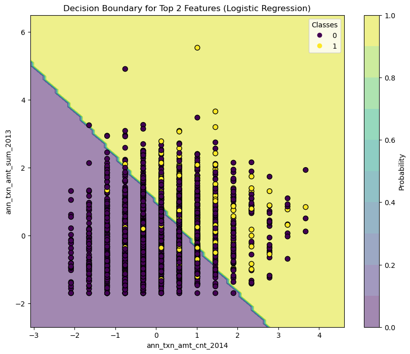

```python
# Train a logistic regression model on the top 2 features
log_reg_top2 = LogisticRegression(penalty='l2', solver='liblinear',class_weight=class_weights)
log_reg_top2.fit(X_top2, y_train_annual)

# Create a meshgrid for plotting the decision boundary
x_min, x_max = X_top2[top_2_features[0]].min() - 1, X_top2[top_2_features[0]].max() + 1
y_min, y_max = X_top2[top_2_features[1]].min() - 1, X_top2[top_2_features[1]].max() + 1
xx, yy = np.meshgrid(np.arange(x_min, x_max, 0.1), np.arange(y_min, y_max, 0.1))

# Predict the class labels for each point in the meshgrid
Z = log_reg_top2.predict(np.c_[xx.ravel(), yy.ravel()])
Z = Z.reshape(xx.shape)

# Plot the decision boundary and training points
plt.figure(figsize=(10, 8))

# Plot decision boundary with color bar
contour = plt.contourf(xx, yy, Z, alpha=0.5, cmap='viridis', levels=np.linspace(0, 1, 11))
plt.colorbar(contour, label='Probability')

# Plot training points
scatter = plt.scatter(X_top2[top_2_features[0]], X_top2[top_2_features[1]], c=y_train_annual, cmap='viridis', s=50, edgecolors='k')
plt.legend(*scatter.legend_elements(), title='Classes')

# Set labels and title
plt.title('Decision Boundary for Top 2 Features (Logistic Regression)')
plt.xlabel(top_2_features[0])
plt.ylabel(top_2_features[1])

# Show the plot
plt.show()
```

# Decision Tree Classifier

```python
from sklearn.tree import DecisionTreeClassifier
from sklearn.model_selection import GridSearchCV, RandomizedSearchCV
import scipy.stats

# Define the parameter grid for Decision Tree (for GridSearchCV)
param_grid = {'max_depth': [10,12,14,16,18, 20],
              'min_samples_split': [2, 4, 6, 8],
              'min_samples_leaf': [3, 4, 8]}
class_weights = {0:0.1,1:0.9}

# Create a Decision Tree classifier
decision_tree = DecisionTreeClassifier(class_weight=class_weights,random_state=1147)

# ------------------------------------ GRID SEARCH ---------------------------------------------------------#
# Initialize GridSearchCV
grid_search_tree = GridSearchCV(decision_tree, param_grid, cv=5)

# Fit the model to the training data
grid_search_tree.fit(X_train_annual, y_train_annual)

# Get the best hyperparameters and the best model
best_params_tree_grid = grid_search_tree.best_params_
best_model_tree_grid = grid_search_tree.best_estimator_

# Print the best hyperparameters for GridSearchCV
print("The best hyperparameters for the Decision Tree model using GridSearchCV are:", best_params_tree_grid)

# --------------------------------- RANDOMIZED SEARCH ------------------------------------------------------#
# Define the parameter distribution for Decision Tree (for RandomizedSearchCV)
param_dist = {'max_depth': scipy.stats.randint(5, 31),
              'min_samples_split': scipy.stats.randint(2, 11),
              'min_samples_leaf': scipy.stats.randint(1, 11)}

# Initialize RandomizedSearchCV
random_search_tree = RandomizedSearchCV(decision_tree, param_distributions=param_dist, n_iter=10, cv=5, random_state=42)

# Fit the model to the training data
random_search_tree.fit(X_train_annual, y_train_annual)

# Get the best hyperparameters and the best model for RandomizedSearchCV
best_params_tree_random = random_search_tree.best_params_
best_model_tree_random = random_search_tree.best_estimator_

# Print the best hyperparameters for RandomizedSearchCV
print("\nThe best hyperparameters for the Decision Tree model using RandomizedSearchCV are:", best_params_tree_random)
```

```
The best hyperparameters for the Decision Tree model using GridSearchCV are: {'max_depth': 20, 'min_samples_leaf': 3, 'min_samples_split': 2}

The best hyperparameters for the Decision Tree model using RandomizedSearchCV are: {'max_depth': 14, 'min_samples_leaf': 3, 'min_samples_split': 8}
```

```python
# Evaluate the model from GridSearchCV on the test set
y_pred_test_tree_grid = best_model_tree_grid.predict(X_test_annual)

# Calculate metrics for GridSearchCV
accuracy_tree_grid = accuracy_score(y_test_annual, y_pred_test_tree_grid)
precision_tree_grid = precision_score(y_test_annual, y_pred_test_tree_grid)
recall_tree_grid = recall_score(y_test_annual, y_pred_test_tree_grid)
f1_tree_grid = f1_score(y_test_annual, y_pred_test_tree_grid)
conf_matrix_tree_grid = confusion_matrix(y_test_annual, y_pred_test_tree_grid)

# Print metrics for GridSearchCV
print("Decision Tree Model Metrics (GridSearchCV):")
print("Accuracy:", accuracy_tree_grid)
print("Precision:", precision_tree_grid)
print("Recall:", recall_tree_grid)
print("F1 Score:", f1_tree_grid)
print("Confusion Matrix:")
print(conf_matrix_tree_grid)

# Evaluate the model from RandomizedSearchCV on the test set
y_pred_test_tree_random = best_model_tree_random.predict(X_test_annual)

# Calculate metrics for RandomizedSearchCV
accuracy_tree_random = accuracy_score(y_test_annual, y_pred_test_tree_random)
precision_tree_random = precision_score(y_test_annual, y_pred_test_tree_random)
recall_tree_random = recall_score(y_test_annual, y_pred_test_tree_random)
f1_tree_random = f1_score(y_test_annual, y_pred_test_tree_random)
conf_matrix_tree_random = confusion_matrix(y_test_annual, y_pred_test_tree_random)

# Print metrics for RandomizedSearchCV
print("\nDecision Tree Model Metrics (RandomizedSearchCV):")
print("Accuracy:", accuracy_tree_random)
print("Precision:", precision_tree_random)
print("Recall:", recall_tree_random)
print("F1 Score:", f1_tree_random)
print("Confusion Matrix:")
print(conf_matrix_tree_random)
```

```
Decision Tree Model Metrics (GridSearchCV):
Accuracy: 0.8106753812636166
Precision: 0.18042813455657492
Recall: 0.2616407982261641
F1 Score: 0.21357466063348415
Confusion Matrix:
[[3603  536]
 [ 333  118]]

Decision Tree Model Metrics (RandomizedSearchCV):
Accuracy: 0.7851851851851852
Precision: 0.1826809015421115
Recall: 0.34146341463414637
F1 Score: 0.23802163833075735
Confusion Matrix:
[[3450  689]
 [ 297  154]]
```

```python
import pandas as pd
import plotly.express as px
from sklearn.tree import plot_tree

feature_importance = best_model_tree_random.feature_importances_
feature_names = X.columns

# Creating a DataFrame with feature names and their corresponding importance
importance_df = pd.DataFrame({'Feature': feature_names, 'Importance': feature_importance})

# Sorting the DataFrame by importance values for better visualization
importance_df = importance_df.sort_values(by='Importance', ascending=True)

# Plotting using Plotly Express
fig = px.bar(importance_df, x='Feature', y='Importance',
             title='Decision Tree Feature Importance in Descending Order',
             labels={'Importance': 'Importance Value', 'Feature': 'Feature'})

fig.show()
```

```python
# Getting predicted probabilities for the positive class
probabilities_tree = best_model_tree_random.predict_proba(X_test_annual)[:, 1]

# Creating a DataFrame with probabilities
prob_df_tree = pd.DataFrame({'Probability': probabilities_tree, 'Actual': y_test_annual})

# Plotting using Plotly Express with borders on the bars
fig_tree = px.histogram(prob_df_tree, x='Probability', color='Actual', marginal='box', title='Probability Distribution for Test Set (Decision Tree)',
                        labels={'Probability': 'Predicted Probability', 'Actual': 'Actual'}, opacity=0.7,
                        barmode='overlay',  # Overlay mode to show bars with borders
                        barnorm='percent',  # Normalize bars to percentage
                        histnorm='probability')

fig_tree.show()
```

```python
from sklearn.metrics import confusion_matrix, precision_score, recall_score
import plotly.graph_objects as go

# Evaluate the model from RandomizedSearchCV on the test set
y_pred_test_tree_random = best_model_tree_random.predict(X_test_annual)

# Evaluate the model from RandomizedSearchCV on the rain set
y_pred_train_tree_random = best_model_tree_random.predict(X_train_annual)

# Confusion matrix for test set - GridSearchCV
conf_matrix_test_tree_grid = confusion_matrix(y_test_annual, y_pred_test_tree_grid)

# Confusion matrix for test set - RandomizedSearchCV
conf_matrix_train_tree_random = confusion_matrix(y_train_annual, y_pred_train_tree_random)

# Calculate precision and recall for test set - GridSearchCV
precision_test_tree_grid = precision_score(y_test_annual, y_pred_test_tree_random)
recall_test_tree_grid = recall_score(y_test_annual, y_pred_test_tree_random)

# Calculate precision and recall for test set - RandomizedSearchCV
precision_train_tree_random = precision_score(y_train_annual, y_pred_train_tree_random)
recall_train_tree_random = recall_score(y_train_annual, y_pred_train_tree_random)

# Create a list to store the text values for each block - TEST
text_values_test_tree_grid = [
    [f'TN: {conf_matrix_test_tree_grid[0, 0]}', f'FP: {conf_matrix_test_tree_grid[0, 1]}'],
    [f'FN: {conf_matrix_test_tree_grid[1, 0]}', f'TP: {conf_matrix_test_tree_grid[1, 1]}']
]

# Create a list to store the text values for each block - TRAIN
text_values_train_tree_random = [
    [f'TN: {conf_matrix_train_tree_random[0, 0]}', f'FP: {conf_matrix_train_tree_random[0, 1]}'],
    [f'FN: {conf_matrix_train_tree_random[1, 0]}', f'TP: {conf_matrix_train_tree_random[1, 1]}']
]

# Plotting Confusion Matrix with text values for test set - GridSearchCV
fig_conf_matrix_test_tree_grid = go.Figure(data=go.Heatmap(z=conf_matrix_test_tree_grid, x=['0', '1'], y=['0', '1'],
                                                          colorscale='Viridis', text=text_values_test_tree_grid, hoverinfo='text'))
fig_conf_matrix_test_tree_grid.update_layout(title='Test Set Confusion Matrix (Decision Tree - RandomizedSearchCV)',
                                             xaxis=dict(title='Predicted', side='bottom'),
                                             yaxis=dict(title='True'), width=1200, height=800)

# Plotting Confusion Matrix with text values for train set - RandomizedSearchCV
fig_conf_matrix_train_tree_random = go.Figure(data=go.Heatmap(z=conf_matrix_train_tree_random, x=['0', '1'], y=['0', '1'],
                                                            colorscale='Viridis', text=text_values_train_tree_random, hoverinfo='text'))
fig_conf_matrix_train_tree_random.update_layout(title='Train Set Confusion Matrix (Decision Tree - RandomizedSearchCV)',
                                               xaxis=dict(title='Predicted', side='bottom'),
                                               yaxis=dict(title='True'), width=1200, height=800)

# Show plots for the test set - GridSearchCV
fig_conf_matrix_test_tree_grid.show()

# Show plots for the test set - RandomizedSearchCV
fig_conf_matrix_train_tree_random.show()

# Print precision and recall for the test set - GridSearchCV
print("Test Set Precision (Decision Tree - RandomizedSearchCV):", precision_test_tree_grid)
print("Test Set Recall (Decision Tree - RandomizedSearchCV):", recall_test_tree_grid)

# Print precision and recall for the train set - RandomizedSearchCV
print("\nTest Set Precision (Decision Tree - RandomizedSearchCV):", precision_train_tree_random)
print("Test Set Recall (Decision Tree - RandomizedSearchCV):", recall_train_tree_random)
```

```
Test Set Precision (Decision Tree - RandomizedSearchCV): 0.1826809015421115
Test Set Recall (Decision Tree - RandomizedSearchCV): 0.34146341463414637

Test Set Precision (Decision Tree - RandomizedSearchCV): 0.5064599483204134
Test Set Recall (Decision Tree - RandomizedSearchCV): 1.0
```

```python
# Predicted probabilities for the positive class for training set
probabilities_train_tree = best_model_tree_random.predict_proba(X_train_annual)[:, 1]
fpr_train_tree, tpr_train_tree, thresholds_train_tree = roc_curve(y_train_annual, probabilities_train_tree)
roc_auc_train_tree = auc(fpr_train_tree, tpr_train_tree)

# Assuming best_model_tree_random is your trained decision tree model
probabilities_test_tree = best_model_tree_random.predict_proba(X_test_annual)[:, 1]
fpr_test_tree, tpr_test_tree, thresholds_test_tree = roc_curve(y_test_annual, probabilities_test_tree)
roc_auc_test_tree = auc(fpr_test_tree, tpr_test_tree)


fpr_test_tree, tpr_test_tree, thresholds_test_tree = roc_curve(y_test_annual, probabilities_test_tree)
roc_auc_test_tree = auc(fpr_test_tree, tpr_test_tree)


# Plotting ROC Curve for both sets
fig_roc_curve_tree = go.Figure()
fig_roc_curve_tree.add_trace(go.Scatter(x=fpr_test_tree, y=tpr_test_tree, mode='lines', name=f'Test Set AUC = {roc_auc_test_tree:.2f}'))
fig_roc_curve_tree.add_trace(go.Scatter(x=fpr_train_tree, y=tpr_train_tree, mode='lines', name=f'Training Set AUC = {roc_auc_train_tree:.2f}'))
fig_roc_curve_tree.add_trace(go.Scatter(x=[0, 1], y=[0, 1], mode='lines', name='Random', line=dict(dash='dash')))
fig_roc_curve_tree.update_layout(title='Receiver Operating Characteristic (ROC) Curve (Decision Tree)',
                                  xaxis=dict(title='False Positive Rate'),
                                  yaxis=dict(title='True Positive Rate'), width=1200, height=800)

# Show the plot
fig_roc_curve_tree.show()
```

```python
top_2_features = importance_df.iloc[-2:,0].values
X_top2_tree = X_train_annual[top_2_features]
```

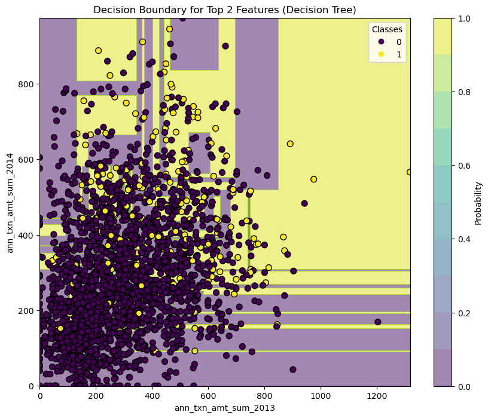

```python
# Create a meshgrid for plotting the decision boundary
x_min, x_max = X_top2_tree[top_2_features[0]].min() - 1, X_top2_tree[top_2_features[0]].max() + 1
y_min, y_max = X_top2_tree[top_2_features[1]].min() - 1, X_top2_tree[top_2_features[1]].max() + 1
xx, yy = np.meshgrid(np.arange(x_min, x_max, 0.1), np.arange(y_min, y_max, 0.1))

# Train a new Decision Tree model on the top 2 features with the hyperparameters from RandomizedSearchCV
decision_tree_top2 = DecisionTreeClassifier(**best_model_tree_random.get_params())
decision_tree_top2.fit(X_top2_tree, y_train_annual)

# Create a meshgrid for plotting the decision boundary
xx, yy = np.meshgrid(np.arange(x_min, x_max, 0.1), np.arange(y_min, y_max, 0.1))

# Predict the class labels and probabilities for each point in the meshgrid
Z_tree = decision_tree_top2.predict(np.c_[xx.ravel(), yy.ravel()])
probs_tree = decision_tree_top2.predict_proba(np.c_[xx.ravel(), yy.ravel()])[:, 1]
Z_tree = Z_tree.reshape(xx.shape)

# Plot the decision boundary and training points
plt.figure(figsize=(10, 8))

# Plot decision boundary with color bar
contour = plt.contourf(xx, yy, Z_tree, alpha=0.5, cmap='viridis', levels=np.linspace(0, 1, 11))
cbar = plt.colorbar(contour, label='Probability')

# Plot training points
scatter = plt.scatter(X_top2_tree[top_2_features[0]], X_top2_tree[top_2_features[1]], c=y_train_annual, cmap='viridis', s=50, edgecolors='k')
plt.legend(*scatter.legend_elements(), title='Classes')

# Set labels and title
plt.title('Decision Boundary for Top 2 Features (Decision Tree)')
plt.xlabel(top_2_features[0])
plt.ylabel(top_2_features[1])

# Show the plot
plt.show()
```

# Random Forest Classifier

```python
from sklearn.ensemble import RandomForestClassifier
from sklearn.model_selection import GridSearchCV, RandomizedSearchCV
import scipy.stats

# Define the parameter grid for Decision Tree (for GridSearchCV)
param_grid_rf = {'max_depth': [10,12,14,16,18,20],
              'min_samples_split': [2, 4, 6],
              'min_samples_leaf': [2, 3, 4]}
class_weights = {0:0.1,1:0.9}


# Create a Random Forest classifier
random_forest = RandomForestClassifier(class_weight=class_weights,random_state=1147)

# ------------------------------------ GRID SEARCH ---------------------------------------------------------#
# Initialize GridSearchCV
grid_search_rf = GridSearchCV(random_forest, param_grid_rf, cv=5)

# Fit the model to the training data
grid_search_rf.fit(X_train_annual, y_train_annual)

# Get the best hyperparameters and the best model for GridSearchCV
best_params_rf_grid = grid_search_rf.best_params_
best_model_rf_grid = grid_search_rf.best_estimator_

# Print the best hyperparameters for GridSearchCV
print("The best hyperparameters for the Random Forest model using GridSearchCV are:", best_params_rf_grid)

# --------------------------------- RANDOMIZED SEARCH ------------------------------------------------------#
# Define the parameter distribution for Random Forest (for RandomizedSearchCV)
param_dist_rf = {
    'max_depth': scipy.stats.randint(5, 31),  # None or random integers between 5 and 20
    'min_samples_split': scipy.stats.randint(2, 11),  # Random integer between 2 and 10
    'min_samples_leaf': scipy.stats.randint(1, 11)
}

# Initialize RandomizedSearchCV
random_search_rf = RandomizedSearchCV(random_forest, param_distributions=param_dist_rf, n_iter=10, cv=5, random_state=42)

# Fit the model to the training data
random_search_rf.fit(X_train_annual, y_train_annual)

# Get the best hyperparameters and the best model for RandomizedSearchCV
best_params_rf_random = random_search_rf.best_params_
best_model_rf_random = random_search_rf.best_estimator_

# Print the best hyperparameters for RandomizedSearchCV
print("\nThe best hyperparameters for the Random Forest model using RandomizedSearchCV are:", best_params_rf_random)
best_model_rf_random
```

```
The best hyperparameters for the Random Forest model using GridSearchCV are: {'max_depth': 18, 'min_samples_leaf': 2, 'min_samples_split': 2}

The best hyperparameters for the Random Forest model using RandomizedSearchCV are: {'max_depth': 14, 'min_samples_leaf': 3, 'min_samples_split': 8}
```

```
RandomForestClassifier(class_weight={0: 0.1, 1: 0.9}, max_depth=14,
                       min_samples_leaf=3, min_samples_split=8,
                       random_state=1147)
```

```python
# Evaluate the model from GridSearchCV on the test set
y_pred_test_rf_grid = best_model_rf_grid.predict(X_test_annual)

# Calculate metrics for GridSearchCV
accuracy_rf_grid = accuracy_score(y_test_annual, y_pred_test_rf_grid)
precision_rf_grid = precision_score(y_test_annual, y_pred_test_rf_grid)
recall_rf_grid = recall_score(y_test_annual, y_pred_test_rf_grid)
f1_rf_grid = f1_score(y_test_annual, y_pred_test_rf_grid)
conf_matrix_rf_grid = confusion_matrix(y_test_annual, y_pred_test_rf_grid)

# Print metrics for GridSearchCV
print("Random Forest Model Metrics (GridSearchCV):")
print("Accuracy:", accuracy_rf_grid)
print("Precision:", precision_rf_grid)
print("Recall:", recall_rf_grid)
print("F1 Score:", f1_rf_grid)
print("Confusion Matrix:")
print(conf_matrix_rf_grid)

# Evaluate the model from RandomizedSearchCV on the test set
y_pred_test_rf_random = best_model_rf_random.predict(X_test_annual)

# Calculate metrics for RandomizedSearchCV
accuracy_rf_random = accuracy_score(y_test_annual, y_pred_test_rf_random)
precision_rf_random = precision_score(y_test_annual, y_pred_test_rf_random)
recall_rf_random = recall_score(y_test_annual, y_pred_test_rf_random)
f1_rf_random = f1_score(y_test_annual, y_pred_test_rf_random)
conf_matrix_rf_random = confusion_matrix(y_test_annual, y_pred_test_rf_random)

# Print metrics for RandomizedSearchCV
print("\nRandom Forest Model Metrics (RandomizedSearchCV):")
print("Accuracy:", accuracy_rf_random)
print("Precision:", precision_rf_random)
print("Recall:", recall_rf_random)
print("F1 Score:", f1_rf_random)
print("Confusion Matrix:")
print(conf_matrix_rf_random)
```

```
Random Forest Model Metrics (GridSearchCV):
Accuracy: 0.8993464052287582
Precision: 0.13333333333333333
Recall: 0.004434589800443459
F1 Score: 0.008583690987124463
Confusion Matrix:
[[4126   13]
 [ 449    2]]

Random Forest Model Metrics (RandomizedSearchCV):
Accuracy: 0.8949891067538126
Precision: 0.26153846153846155
Recall: 0.037694013303769404
F1 Score: 0.06589147286821705
Confusion Matrix:
[[4091   48]
 [ 434   17]]
```

```python
import pandas as pd
import plotly.express as px

feature_importance_rf = best_model_rf_grid.feature_importances_
feature_names_rf = X.columns

# Creating a DataFrame with feature names and their corresponding importance
importance_df_rf = pd.DataFrame({'Feature': feature_names_rf, 'Importance': feature_importance_rf})

# Sorting the DataFrame by importance values for better visualization
importance_df_rf = importance_df_rf.sort_values(by='Importance', ascending=True)

# Plotting using Plotly Express
fig_rf = px.bar(importance_df_rf, x='Feature', y='Importance',
                title='Random Forest Feature Importance in Descending Order',
                labels={'Importance': 'Importance Value', 'Feature': 'Feature'})

fig_rf.show()
```

```python
# Getting predicted probabilities  for Random Forest
probabilities_rf = best_model_rf_grid.predict_proba(X_test_annual)[:, 1]

# Creating a DataFrame with probabilities for Random Forest
prob_df_rf = pd.DataFrame({'Probability': probabilities_rf, 'Actual': y_test_annual})

# Plotting using Plotly Express with borders on the bars for Random Forest
fig_rf = px.histogram(prob_df_rf, x='Probability', color='Actual', marginal='box',
                      title='Probability Distribution for Test Set (Random Forest)',
                      labels={'Probability': 'Predicted Probability', 'Actual': 'Actual'},
                      opacity=0.7,
                      barmode='overlay',  # Overlay mode to show bars with borders
                      barnorm='percent',  # Normalize bars to percentage
                      histnorm='probability')

fig_rf.show()
```

```python
from sklearn.metrics import confusion_matrix, precision_score, recall_score
import plotly.graph_objects as go

# Evaluate the model from GridSearchCV on the train set
y_pred_train_rf_grid = best_model_rf_grid.predict(X_train_annual)

# Evaluate the model from RandomizedSearchCV on the test set
y_pred_test_rf_random = best_model_rf_random.predict(X_test_annual)

# Confusion matrix for train set - RandomizedSearchCV
conf_matrix_train_rf_random = confusion_matrix(y_train_annual, y_pred_train_rf_grid)

# Confusion matrix for test set - RandomizedSearchCV
conf_matrix_test_rf_random = confusion_matrix(y_test_annual, y_pred_test_rf_random)

# Calculate precision and recall for train set - RandomizedSearchCV
precision_train_rf_random = precision_score(y_train_annual, y_pred_train_rf_grid)
recall_train_rf_random = recall_score(y_test_annual, y_pred_test_rf_grid)

# Calculate precision and recall for test set - RandomizedSearchCV
precision_test_rf_random = precision_score(y_test_annual, y_pred_test_rf_random)
recall_test_rf_random = recall_score(y_test_annual, y_pred_test_rf_random)

# Create a list to store the text values for each block - RandomizedSearchCV
text_values_test_rf_random = [
    [f'TN: {conf_matrix_test_rf_random[0, 0]}', f'FP: {conf_matrix_test_rf_random[0, 1]}'],
    [f'FN: {conf_matrix_test_rf_random[1, 0]}', f'TP: {conf_matrix_test_rf_random[1, 1]}']
]

# Create a list to store the text values for each block - RandomizedSearchCV
text_values_train_rf_random = [
    [f'TN: {conf_matrix_train_rf_random[0, 0]}', f'FP: {conf_matrix_train_rf_random[0, 1]}'],
    [f'FN: {conf_matrix_train_rf_random[1, 0]}', f'TP: {conf_matrix_train_rf_random[1, 1]}']
]

# Plotting Confusion Matrix with text values for train set - GridSearchCV
fig_conf_matrix_train_rf_random = go.Figure(data=go.Heatmap(z=conf_matrix_train_rf_random, x=['0', '1'], y=['0', '1'],
                                                          colorscale='Viridis', text=text_values_train_rf_random, hoverinfo='text'))
fig_conf_matrix_train_rf_random.update_layout(title='Train Set Confusion Matrix (Random Forest - RandomizedSearchCV)',
                                             xaxis=dict(title='Predicted', side='bottom'),
                                             yaxis=dict(title='True'), width=1200, height=800)

# Plotting Confusion Matrix with text values for test set - RandomizedSearchCV
fig_conf_matrix_test_rf_random = go.Figure(data=go.Heatmap(z=conf_matrix_test_rf_random, x=['0', '1'], y=['0', '1'],
                                                            colorscale='Viridis', text=text_values_test_rf_random, hoverinfo='text'))
fig_conf_matrix_test_rf_random.update_layout(title='Test Set Confusion Matrix (Random Forest - RandomizedSearchCV)',
                                               xaxis=dict(title='Predicted', side='bottom'),
                                               yaxis=dict(title='True'), width=1200, height=800)

# Show plots for the test set - GridSearchCV
fig_conf_matrix_train_rf_random.show()

# Show plots for the test set - RandomizedSearchCV
fig_conf_matrix_test_rf_random.show()

# Print precision and recall for the test set - GridSearchCV
print("Train Set Precision (Random Forest - GridSearchCV):", precision_train_rf_random)
print("Train Set Recall (Random Forest - GridSearchCV):", recall_train_rf_random)

# Print precision and recall for the test set - RandomizedSearchCV
print("\nTest Set Precision (Random Forest - RandomizedSearchCV):", precision_test_rf_random)
print("Test Set Recall (Random Forest - RandomizedSearchCV):", recall_test_rf_random)
```

```
Train Set Precision (Random Forest - GridSearchCV): 1.0
Train Set Recall (Random Forest - GridSearchCV): 0.004434589800443459

Test Set Precision (Random Forest - RandomizedSearchCV): 0.26153846153846155
Test Set Recall (Random Forest - RandomizedSearchCV): 0.037694013303769404
```

```python
# Predicted probabilities for the positive class for test set for Random Forest
probabilities_test_rf = best_model_rf_grid.predict_proba(X_test_annual)[:, 1]
fpr_test_rf, tpr_test_rf, thresholds_test_rf = roc_curve(y_test_annual, probabilities_test_rf)
roc_auc_test_rf = auc(fpr_test_rf, tpr_test_rf)

# Predicted probabilities for the positive class for training set for Random Forest
probabilities_train_rf = best_model_rf_grid.predict_proba(X_train_annual)[:, 1]
fpr_train_rf, tpr_train_rf, thresholds_train_rf = roc_curve(y_train_annual, probabilities_train_rf)
roc_auc_train_rf = auc(fpr_train_rf, tpr_train_rf)

# Plotting ROC Curve for both sets for Random Forest
fig_roc_curve_rf = go.Figure()
fig_roc_curve_rf.add_trace(go.Scatter(x=fpr_test_rf, y=tpr_test_rf, mode='lines', name=f'Test Set AUC = {roc_auc_test_rf:.2f}'))
fig_roc_curve_rf.add_trace(go.Scatter(x=fpr_train_rf, y=tpr_train_rf, mode='lines', name=f'Training Set AUC = {roc_auc_train_rf:.2f}'))
fig_roc_curve_rf.add_trace(go.Scatter(x=[0, 1], y=[0, 1], mode='lines', name='Random', line=dict(dash='dash')))
fig_roc_curve_rf.update_layout(title='Receiver Operating Characteristic (ROC) Curve (Random Forest)',
                               xaxis=dict(title='False Positive Rate'),
                               yaxis=dict(title='True Positive Rate'), width=1200, height=800)

# Show the plot for Random Forest
fig_roc_curve_rf.show()
```

```python
top_2_features = importance_df_rf.iloc[-2:,0].values
X_top2_rf = X_train_annual[top_2_features]
```

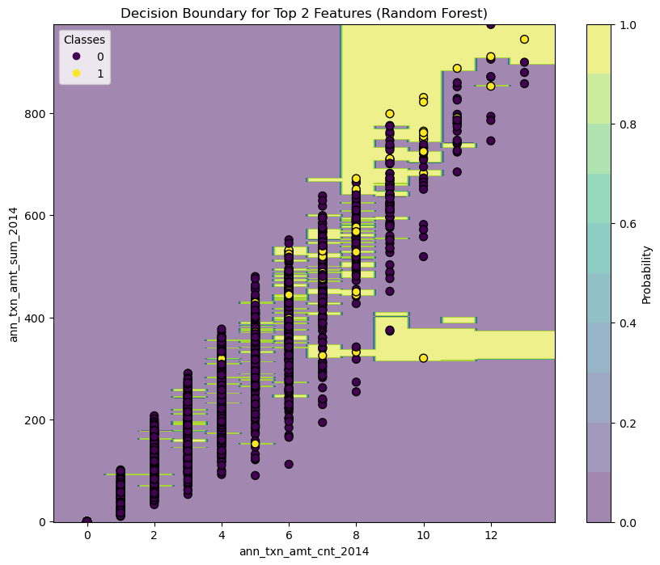

```python
# Create a meshgrid for plotting the decision boundary
x_min, x_max = X_top2_rf[top_2_features[0]].min() - 1, X_top2_rf[top_2_features[0]].max() + 1
y_min, y_max = X_top2_rf[top_2_features[1]].min() - 1, X_top2_rf[top_2_features[1]].max() + 1
xx, yy = np.meshgrid(np.arange(x_min, x_max, 0.1), np.arange(y_min, y_max, 0.1))

# Train a new Random Forest model on the top 2 features with the hyperparameters from GridSearchCV
decision_rf_top2 = RandomForestClassifier(**best_model_rf_grid.get_params())
decision_rf_top2.fit(X_top2_rf, y_train_annual)

# Create a meshgrid for plotting the decision boundary
xx, yy = np.meshgrid(np.arange(x_min, x_max, 0.1), np.arange(y_min, y_max, 0.1))

# Predict the class labels and probabilities for each point in the meshgrid
Z_rf = decision_rf_top2.predict(np.c_[xx.ravel(), yy.ravel()])
probs_rf = decision_rf_top2.predict_proba(np.c_[xx.ravel(), yy.ravel()])[:, 1]
Z_rf = Z_rf.reshape(xx.shape)

# Plot the decision boundary and training points
plt.figure(figsize=(10, 8))

# Plot decision boundary with color bar
contour = plt.contourf(xx, yy, Z_rf, alpha=0.5, cmap='viridis', levels=np.linspace(0, 1, 11))
cbar = plt.colorbar(contour, label='Probability')

# Plot training points
scatter = plt.scatter(X_top2_rf[top_2_features[0]], X_top2_rf[top_2_features[1]], c=y_train_annual, cmap='viridis', s=50, edgecolors='k')
plt.legend(*scatter.legend_elements(), title='Classes')

# Set labels and title
plt.title('Decision Boundary for Top 2 Features (Random Forest)')
plt.xlabel(top_2_features[0])
plt.ylabel(top_2_features[1])

# Show the plot
plt.show()
```

# Steps (Data Preparation for Machine Learning Model training)

# monthly_features

### 1.2.1 Separating X and y

```python
X = monthly_features_outputs.drop(['response','CLNT_NO','ME_DT'],axis=1)
y = monthly_features_outputs['response']
display(X)
display(y)
```

|  | mth_txn_amt_sum | mth_txn_cnt | amt_sum_3M | amt_mean_3M | amt_max_3M | txn_cnt_sum_3M | txn_cnt_mean_3M | txn_cnt_max_3M | amt_sum_6M | amt_mean_6M | ... | txn_cnt_mean_12M | txn_cnt_max_12M | cnt_Friday | cnt_Monday | cnt_Saturday | cnt_Sunday | cnt_Thursday | cnt_Tuesday | cnt_Wednesday | days_since_last_txn |
| --- | --- | --- | --- | --- | --- | --- | --- | --- | --- | --- | --- | --- | --- | --- | --- | --- | --- | --- | --- | --- | --- |
| 0 | 0 | 0 | 0.0 | 0.000000 | 0.0 | 0.0 | 0.000000 | 0.0 | 0.0 | 0.000000 | ... | 0.000000 | 0.0 | 0 | 0 | 0 | 0 | 0 | 0 | 0 | 0 |
| 1 | 56 | 1 | 0.0 | 0.000000 | 0.0 | 0.0 | 0.000000 | 0.0 | 0.0 | 0.000000 | ... | 0.000000 | 0.0 | 0 | 0 | 0 | 0 | 0 | 0 | 1 | 15 |
| 2 | 0 | 0 | 56.0 | 18.666667 | 56.0 | 1.0 | 0.333333 | 1.0 | 0.0 | 0.000000 | ... | 0.000000 | 0.0 | 0 | 0 | 0 | 0 | 0 | 0 | 0 | 46 |
| 3 | 96 | 1 | 152.0 | 50.666667 | 96.0 | 2.0 | 0.666667 | 1.0 | 0.0 | 0.000000 | ... | 0.000000 | 0.0 | 1 | 0 | 0 | 0 | 0 | 0 | 0 | 12 |
| 4 | 0 | 0 | 96.0 | 32.000000 | 96.0 | 1.0 | 0.333333 | 1.0 | 0.0 | 0.000000 | ... | 0.000000 | 0.0 | 0 | 0 | 0 | 0 | 0 | 0 | 0 | 42 |
| ... | ... | ... | ... | ... | ... | ... | ... | ... | ... | ... | ... | ... | ... | ... | ... | ... | ... | ... | ... | ... | ... |
| 323543 | 0 | 0 | 0.0 | 0.000000 | 0.0 | 0.0 | 0.000000 | 0.0 | 61.0 | 10.166667 | ... | 0.333333 | 1.0 | 0 | 0 | 0 | 0 | 0 | 0 | 0 | 98 |
| 323544 | 0 | 0 | 0.0 | 0.000000 | 0.0 | 0.0 | 0.000000 | 0.0 | 61.0 | 10.166667 | ... | 0.333333 | 1.0 | 0 | 0 | 0 | 0 | 0 | 0 | 0 | 129 |
| 323545 | 0 | 0 | 0.0 | 0.000000 | 0.0 | 0.0 | 0.000000 | 0.0 | 35.0 | 5.833333 | ... | 0.250000 | 1.0 | 0 | 0 | 0 | 0 | 0 | 0 | 0 | 160 |
| 323546 | 34 | 1 | 34.0 | 11.333333 | 34.0 | 1.0 | 0.333333 | 1.0 | 34.0 | 5.666667 | ... | 0.333333 | 1.0 | 0 | 0 | 1 | 0 | 0 | 0 | 0 | 0 |
| 323547 | 0 | 0 | 34.0 | 11.333333 | 34.0 | 1.0 | 0.333333 | 1.0 | 34.0 | 5.666667 | ... | 0.333333 | 1.0 | 0 | 0 | 0 | 0 | 0 | 0 | 0 | 31 |

323548 rows × 28 columns

```
0         0
1         0
2         0
3         0
4         0
         ..
323543    0
323544    0
323545    0
323546    0
323547    0
Name: response, Length: 323548, dtype: int64
```

### 1.2.2 Splitting the dataset into Training and Test Set [Test Size = 2/3 & random_state = 1147]

```python
X_train_monthly, X_test_monthly, y_train_monthly, y_test_monthly = train_test_split(X, y, test_size=2/3, random_state=1147)

print("The length of the training set is {}, while the length of the testing set is {}".format(len(X_train_monthly), len(X_test_monthly)))
```

```
The length of the training set is 107849, while the length of the testing set is 215699
```

### 1.2.3 Data Preprocessing

```python
scaler = StandardScaler()

X_train_monthly_scaled = scaler.fit_transform(X_train_monthly)
X_test_monthly_scaled = scaler.transform(X_test_monthly)
```

# Logistic Regression with L1 Regularization

### 1.2.4 Fitting the Training Data and Hypertuning the model using Grid Search

```python
param_grid = {'C': [0.1, 1, 10]}
class_weights = {0:0.1,1:0.9}
log_reg = LogisticRegression(penalty='l1', solver='liblinear',class_weight=class_weights)

grid_search = GridSearchCV(log_reg, param_grid, cv=5)
grid_search.fit(X_train_monthly_scaled, y_train_monthly)

best_params = grid_search.best_params_
best_model = grid_search.best_estimator_

# Predictions on the train set
y_pred_train = best_model.predict(X_train_monthly_scaled)
# Predictions on the test set
y_pred_test = best_model.predict(X_test_monthly_scaled)


print("The best hyperparameters for the model is:",best_params)
best_model
```

```
The best hyperparameters for the model is: {'C': 10}
```

```
LogisticRegression(C=10, class_weight={0: 0.1, 1: 0.9}, penalty='l1',
                   solver='liblinear')
```

```python
accuracy = accuracy_score(y_test_monthly, y_pred_test)
precision = precision_score(y_test_monthly, y_pred_test)
recall = recall_score(y_test_monthly, y_pred_test)
f1 = f1_score(y_test_monthly, y_pred_test)
conf_matrix = confusion_matrix(y_test_monthly, y_pred_test)

print("Accuracy:", accuracy)
print("Precision:", precision)
print("Recall:", recall)
print("F1 Score:", f1)
print("Confusion Matrix:")
print(conf_matrix)
```

```
Accuracy: 0.6708422384897473
Precision: 0.1362416588935926
Recall: 0.46763865629002066
F1 Score: 0.21100825674819698
Confusion Matrix:
[[135206  60191]
 [ 10808   9494]]
```

### 1.2.5 Feature Importance

```python
coefficients = best_model.coef_[0]

feature_names = X.columns

# Creating a DataFrame with feature names and their corresponding coefficients
coef_df = pd.DataFrame({'Feature': feature_names, 'Coefficient': coefficients})

# Sorting the DataFrame by coefficient values for better visualization
coef_df = coef_df.sort_values(by='Coefficient', ascending=True)

# Plotting using Plotly Express
fig = px.bar(coef_df, x='Feature', y='Coefficient', title='Logistic Regression Coefficients shwoing the Feature Importance in Ascending order (MONTHLY FEATURES)',
             labels={'Coefficient': 'Coefficient Value', 'Feature': 'Feature'})

fig.show()
```

### 1.2.6 Probability Distribution for Test Set

```python
# Getting predicted probabilities for the positive class
probabilities = best_model.predict_proba(X_test_monthly_scaled)[:, 1]

# Creating a DataFrame with probabilities
prob_df = pd.DataFrame({'Probability': probabilities, 'Actual': y_test_monthly})

# Plotting using Plotly Express with borders on the bars
fig = px.histogram(prob_df, x='Probability', color='Actual', marginal='box', title='Probability Distribution for Test Set (MONTHLY FEATURES)',
                   labels={'Probability': 'Predicted Probability', 'Actual': 'Actual'}, opacity=0.7,
                   barmode='overlay', # Overlay mode to show bars with borders
                   barnorm='percent', # Normalize bars to percentage
                   histnorm='probability')

fig.show()
```

### 1.2.7 Confusion Matrix & ROC Curve for Training/Test set

### Precision & Recall for Training/Test set

```python
# Confusion matrix for test set
conf_matrix_test = confusion_matrix(y_test_monthly, y_pred_test)

# Confusion matrix for training set
conf_matrix_train = confusion_matrix(y_train_monthly, y_pred_train)

# Calculate precision and recall for test set
precision_test = precision_score(y_test_monthly, y_pred_test)
recall_test = recall_score(y_test_monthly, y_pred_test)

# Calculate precision and recall for training set
precision_train = precision_score(y_train_monthly, y_pred_train)
recall_train = recall_score(y_train_monthly, y_pred_train)

# Create a list to store the text values for each block
text_values_test = [
    [f'TN: {conf_matrix_test[0, 0]}', f'FP: {conf_matrix_test[0, 1]}'],
    [f'FN: {conf_matrix_test[1, 0]}', f'TP: {conf_matrix_test[1, 1]}']
]

text_values_train = [
    [f'TN: {conf_matrix_train[0, 0]}', f'FP: {conf_matrix_train[0, 1]}'],
    [f'FN: {conf_matrix_train[1, 0]}', f'TP: {conf_matrix_train[1, 1]}']
]

# Plotting Confusion Matrix with text values for test set
fig_conf_matrix_test = go.Figure(data=go.Heatmap(z=conf_matrix_test, x=['0', '1'], y=['0', '1'],
                                                colorscale='Viridis', text=text_values_test, hoverinfo='text'))
fig_conf_matrix_test.update_layout(title='Test Set Confusion Matrix',
                                   xaxis=dict(title='Predicted', side='bottom'),
                                   yaxis=dict(title='True'), width=1200, height=800)

# Plotting Confusion Matrix with text values for training set
fig_conf_matrix_train = go.Figure(data=go.Heatmap(z=conf_matrix_train, x=['0', '1'], y=['0', '1'],
                                                 colorscale='Viridis', text=text_values_train, hoverinfo='text'))
fig_conf_matrix_train.update_layout(title='Training Set Confusion Matrix',
                                    xaxis=dict(title='Predicted', side='bottom'),
                                    yaxis=dict(title='True'), width=1200, height=800)

# Show plots for the test set
fig_conf_matrix_test.show()

# Show plots for the training set
fig_conf_matrix_train.show()
```

```python
# Print precision and recall for the test set
print("Test Set Precision:", precision_test)
print("Test Set Recall:", recall_test)

# Print precision and recall for the training set
print("Training Set Precision:", precision_train)
print("Training Set Recall:", recall_train)
```

```
Test Set Precision: 0.1362416588935926
Test Set Recall: 0.46763865629002066
Training Set Precision: 0.13699803065330937
Training Set Recall: 0.4749183734045711
```

### ROC Curve for Training/Test set

```python
# ROC curve for test set
fpr_test, tpr_test, thresholds_test = roc_curve(y_test_monthly, best_model.predict_proba(X_test_monthly_scaled)[:, 1])
roc_auc_test = auc(fpr_test, tpr_test)

# ROC curve for training set
fpr_train, tpr_train, thresholds_train = roc_curve(y_train_monthly, best_model.predict_proba(X_train_monthly_scaled)[:, 1])
roc_auc_train = auc(fpr_train, tpr_train)

# Plotting ROC Curve for both sets
fig_roc_curve = go.Figure()
fig_roc_curve.add_trace(go.Scatter(x=fpr_test, y=tpr_test, mode='lines', name=f'Test Set AUC = {roc_auc_test:.2f}'))
fig_roc_curve.add_trace(go.Scatter(x=fpr_train, y=tpr_train, mode='lines', name=f'Training Set AUC = {roc_auc_train:.2f}'))
fig_roc_curve.add_trace(go.Scatter(x=[0, 1], y=[0, 1], mode='lines', name='Random', line=dict(dash='dash')))
fig_roc_curve.update_layout(title='Receiver Operating Characteristic (ROC) Curve',
                            xaxis=dict(title='False Positive Rate'),
                            yaxis=dict(title='True Positive Rate'), width=1200, height=800)

# Show the plot
fig_roc_curve.show()
```

### 1.2.8 Decision Boundary for Top 2 Features

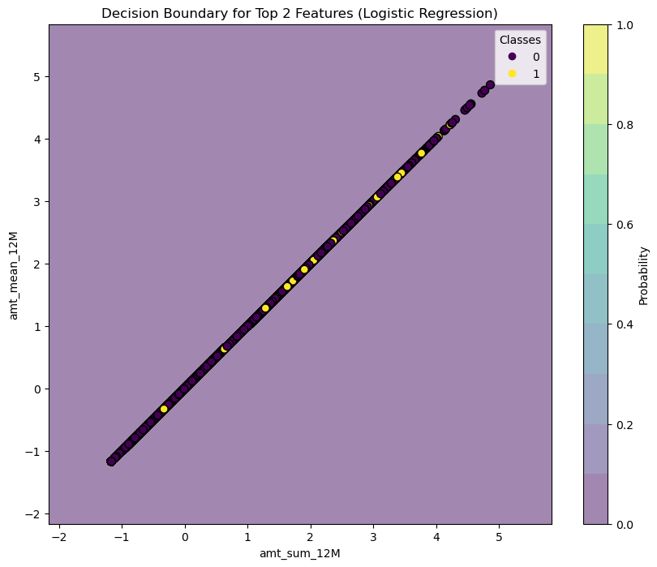

```python
X_train_monthly_scaled = pd.DataFrame(X_train_monthly_scaled, columns=X_train_monthly.columns)
top_2_features = coef_df.iloc[-2:,0].values
X_top2 = X_train_monthly_scaled[top_2_features]

# Train a logistic regression model on the top 2 features
log_reg_top2 = LogisticRegression(penalty='l2', solver='liblinear',C=1)
log_reg_top2.fit(X_top2, y_train_monthly)

# Create a meshgrid for plotting the decision boundary
x_min, x_max = X_top2[top_2_features[0]].min() - 1, X_top2[top_2_features[0]].max() + 1
y_min, y_max = X_top2[top_2_features[1]].min() - 1, X_top2[top_2_features[1]].max() + 1
xx, yy = np.meshgrid(np.arange(x_min, x_max, 0.1), np.arange(y_min, y_max, 0.1))

# Predict the class labels for each point in the meshgrid
Z = log_reg_top2.predict(np.c_[xx.ravel(), yy.ravel()])
Z = Z.reshape(xx.shape)

# Plot the decision boundary and training points
plt.figure(figsize=(10, 8))

# Plot decision boundary with color bar
contour = plt.contourf(xx, yy, Z, alpha=0.5, cmap='viridis', levels=np.linspace(0, 1, 11))
plt.colorbar(contour, label='Probability')

# Plot training points
scatter = plt.scatter(X_top2[top_2_features[0]], X_top2[top_2_features[1]], c=y_train_monthly, cmap='viridis', s=50, edgecolors='k')
plt.legend(*scatter.legend_elements(), title='Classes')

# Set labels and title
plt.title('Decision Boundary for Top 2 Features (Logistic Regression)')
plt.xlabel(top_2_features[0])
plt.ylabel(top_2_features[1])

# Show the plot
plt.show()
```

# Decision Tree Classifier

```python
# Define the parameter grid for Decision Tree (for GridSearchCV)
param_grid = {'max_depth': [10,12,14,16,18, 20],
              'min_samples_split': [2, 4, 6, 8],
              'min_samples_leaf': [3, 4, 8]}
class_weights = {0:0.1,1:0.9}

# Create a Decision Tree classifier
decision_tree = DecisionTreeClassifier(class_weight=class_weights,random_state=1147)

# ------------------------------------ GRID SEARCH ---------------------------------------------------------#
# Initialize GridSearchCV
grid_search_tree = GridSearchCV(decision_tree, param_grid, cv=5)

# Fit the model to the training data
grid_search_tree.fit(X_train_monthly, y_train_monthly)

# Get the best hyperparameters and the best model
best_params_tree_grid = grid_search_tree.best_params_
best_model_tree_grid = grid_search_tree.best_estimator_

# Print the best hyperparameters for GridSearchCV
print("The best hyperparameters for the Decision Tree model using GridSearchCV are:", best_params_tree_grid)

# --------------------------------- RANDOMIZED SEARCH ------------------------------------------------------#
# Define the parameter distribution for Decision Tree (for RandomizedSearchCV)
param_dist = {'max_depth': scipy.stats.randint(5, 31),
              'min_samples_split': scipy.stats.randint(2, 11),
              'min_samples_leaf': scipy.stats.randint(1, 11)}

# Initialize RandomizedSearchCV
random_search_tree = RandomizedSearchCV(decision_tree, param_distributions=param_dist, n_iter=10, cv=5, random_state=42)

# Fit the model to the training data
random_search_tree.fit(X_train_monthly, y_train_monthly)

# Get the best hyperparameters and the best model for RandomizedSearchCV
best_params_tree_random = random_search_tree.best_params_
best_model_tree_random = random_search_tree.best_estimator_

# Print the best hyperparameters for RandomizedSearchCV
print("\nThe best hyperparameters for the Decision Tree model using RandomizedSearchCV are:", best_params_tree_random)
```

```
The best hyperparameters for the Decision Tree model using GridSearchCV are: {'max_depth': 20, 'min_samples_leaf': 3, 'min_samples_split': 2}

The best hyperparameters for the Decision Tree model using RandomizedSearchCV are: {'max_depth': 27, 'min_samples_leaf': 8, 'min_samples_split': 6}
```

```python
# Evaluate the model from GridSearchCV on the test set
y_pred_test_tree_grid = best_model_tree_grid.predict(X_test_monthly)

# Calculate metrics for GridSearchCV
accuracy_tree_grid = accuracy_score(y_test_monthly, y_pred_test_tree_grid)
precision_tree_grid = precision_score(y_test_monthly, y_pred_test_tree_grid)
recall_tree_grid = recall_score(y_test_monthly, y_pred_test_tree_grid)
f1_tree_grid = f1_score(y_test_monthly, y_pred_test_tree_grid)
conf_matrix_tree_grid = confusion_matrix(y_test_monthly, y_pred_test_tree_grid)

# Print metrics for GridSearchCV
print("Decision Tree Model Metrics (GridSearchCV):")
print("Accuracy:", accuracy_tree_grid)
print("Precision:", precision_tree_grid)
print("Recall:", recall_tree_grid)
print("F1 Score:", f1_tree_grid)
print("Confusion Matrix:")
print(conf_matrix_tree_grid)

# Evaluate the model from RandomizedSearchCV on the test set
y_pred_test_tree_random = best_model_tree_random.predict(X_test_monthly)

# Calculate metrics for RandomizedSearchCV
accuracy_tree_random = accuracy_score(y_test_monthly, y_pred_test_tree_random)
precision_tree_random = precision_score(y_test_monthly, y_pred_test_tree_random)
recall_tree_random = recall_score(y_test_monthly, y_pred_test_tree_random)
f1_tree_random = f1_score(y_test_monthly, y_pred_test_tree_random)
conf_matrix_tree_random = confusion_matrix(y_test_monthly, y_pred_test_tree_random)

# Print metrics for RandomizedSearchCV
print("\nDecision Tree Model Metrics (RandomizedSearchCV):")
print("Accuracy:", accuracy_tree_random)
print("Precision:", precision_tree_random)
print("Recall:", recall_tree_random)
print("F1 Score:", f1_tree_random)
print("Confusion Matrix:")
print(conf_matrix_tree_random)
```

```
Decision Tree Model Metrics (GridSearchCV):
Accuracy: 0.6620893003676419
Precision: 0.1360547042620046
Recall: 0.4841394936459462
F1 Score: 0.212415581608947
Confusion Matrix:
[[132983  62414]
 [ 10473   9829]]

Decision Tree Model Metrics (RandomizedSearchCV):
Accuracy: 0.6774254864417545
Precision: 0.1330006702912043
Recall: 0.43980888582405675
F1 Score: 0.20423848027722818
Confusion Matrix:
[[137191  58206]
 [ 11373   8929]]
```

```python
feature_importance = best_model_tree_random.feature_importances_
feature_names = X.columns

# Creating a DataFrame with feature names and their corresponding importance
importance_df = pd.DataFrame({'Feature': feature_names, 'Importance': feature_importance})

# Sorting the DataFrame by importance values for better visualization
importance_df = importance_df.sort_values(by='Importance', ascending=True)

# Plotting using Plotly Express
fig = px.bar(importance_df, x='Feature', y='Importance',
             title='Decision Tree Feature Importance in Descending Order',
             labels={'Importance': 'Importance Value', 'Feature': 'Feature'})

fig.show()
```

```python
# Getting predicted probabilities for the positive class
probabilities_tree = best_model_tree_random.predict_proba(X_test_monthly)[:, 1]

# Creating a DataFrame with probabilities
prob_df_tree = pd.DataFrame({'Probability': probabilities_tree, 'Actual': y_test_monthly})

# Plotting using Plotly Express with borders on the bars
fig_tree = px.histogram(prob_df_tree, x='Probability', color='Actual', marginal='box', title='Probability Distribution for Test Set (Decision Tree)',
                        labels={'Probability': 'Predicted Probability', 'Actual': 'Actual'}, opacity=0.7,
                        barmode='overlay',  # Overlay mode to show bars with borders
                        barnorm='percent',  # Normalize bars to percentage
                        histnorm='probability')

fig_tree.show()
```

```python
from sklearn.metrics import confusion_matrix, precision_score, recall_score
import plotly.graph_objects as go

# Evaluate the model from RandomizedSearchCV on the test set
y_pred_test_tree_random = best_model_tree_random.predict(X_test_monthly)

# Evaluate the model from RandomizedSearchCV on the rain set
y_pred_train_tree_random = best_model_tree_random.predict(X_train_monthly)

# Confusion matrix for test set - GridSearchCV
conf_matrix_test_tree_grid = confusion_matrix(y_test_monthly, y_pred_test_tree_grid)

# Confusion matrix for test set - RandomizedSearchCV
conf_matrix_train_tree_random = confusion_matrix(y_train_monthly, y_pred_train_tree_random)

# Calculate precision and recall for test set - GridSearchCV
precision_test_tree_grid = precision_score(y_test_monthly, y_pred_test_tree_random)
recall_test_tree_grid = recall_score(y_test_monthly, y_pred_test_tree_random)

# Calculate precision and recall for test set - RandomizedSearchCV
precision_train_tree_random = precision_score(y_train_monthly, y_pred_train_tree_random)
recall_train_tree_random = recall_score(y_train_monthly, y_pred_train_tree_random)

# Create a list to store the text values for each block - TEST
text_values_test_tree_grid = [
    [f'TN: {conf_matrix_test_tree_grid[0, 0]}', f'FP: {conf_matrix_test_tree_grid[0, 1]}'],
    [f'FN: {conf_matrix_test_tree_grid[1, 0]}', f'TP: {conf_matrix_test_tree_grid[1, 1]}']
]

# Create a list to store the text values for each block - TRAIN
text_values_train_tree_random = [
    [f'TN: {conf_matrix_train_tree_random[0, 0]}', f'FP: {conf_matrix_train_tree_random[0, 1]}'],
    [f'FN: {conf_matrix_train_tree_random[1, 0]}', f'TP: {conf_matrix_train_tree_random[1, 1]}']
]

# Plotting Confusion Matrix with text values for test set - GridSearchCV
fig_conf_matrix_test_tree_grid = go.Figure(data=go.Heatmap(z=conf_matrix_test_tree_grid, x=['0', '1'], y=['0', '1'],
                                                          colorscale='Viridis', text=text_values_test_tree_grid, hoverinfo='text'))
fig_conf_matrix_test_tree_grid.update_layout(title='Test Set Confusion Matrix (Decision Tree - RandomizedSearchCV)',
                                             xaxis=dict(title='Predicted', side='bottom'),
                                             yaxis=dict(title='True'), width=1200, height=800)

# Plotting Confusion Matrix with text values for train set - RandomizedSearchCV
fig_conf_matrix_train_tree_random = go.Figure(data=go.Heatmap(z=conf_matrix_train_tree_random, x=['0', '1'], y=['0', '1'],
                                                            colorscale='Viridis', text=text_values_train_tree_random, hoverinfo='text'))
fig_conf_matrix_train_tree_random.update_layout(title='Train Set Confusion Matrix (Decision Tree - RandomizedSearchCV)',
                                               xaxis=dict(title='Predicted', side='bottom'),
                                               yaxis=dict(title='True'), width=1200, height=800)

# Show plots for the test set - GridSearchCV
fig_conf_matrix_test_tree_grid.show()

# Show plots for the test set - RandomizedSearchCV
fig_conf_matrix_train_tree_random.show()

# Print precision and recall for the test set - GridSearchCV
print("Test Set Precision (Decision Tree - RandomizedSearchCV):", precision_test_tree_grid)
print("Test Set Recall (Decision Tree - RandomizedSearchCV):", recall_test_tree_grid)

# Print precision and recall for the train set - RandomizedSearchCV
print("\nTest Set Precision (Decision Tree - RandomizedSearchCV):", precision_train_tree_random)
print("Test Set Recall (Decision Tree - RandomizedSearchCV):", recall_train_tree_random)
```

```
Test Set Precision (Decision Tree - RandomizedSearchCV): 0.1330006702912043
Test Set Recall (Decision Tree - RandomizedSearchCV): 0.43980888582405675

Test Set Precision (Decision Tree - RandomizedSearchCV): 0.2712756467439786
Test Set Recall (Decision Tree - RandomizedSearchCV): 0.9026417334520629
```

```python
# Predicted probabilities for the positive class for training set
probabilities_train_tree = best_model_tree_random.predict_proba(X_train_monthly)[:, 1]
fpr_train_tree, tpr_train_tree, thresholds_train_tree = roc_curve(y_train_monthly, probabilities_train_tree)
roc_auc_train_tree = auc(fpr_train_tree, tpr_train_tree)

# Assuming best_model_tree_random is your trained decision tree model
probabilities_test_tree = best_model_tree_random.predict_proba(X_test_monthly)[:, 1]
fpr_test_tree, tpr_test_tree, thresholds_test_tree = roc_curve(y_test_monthly, probabilities_test_tree)
roc_auc_test_tree = auc(fpr_test_tree, tpr_test_tree)


fpr_test_tree, tpr_test_tree, thresholds_test_tree = roc_curve(y_test_monthly, probabilities_test_tree)
roc_auc_test_tree = auc(fpr_test_tree, tpr_test_tree)


# Plotting ROC Curve for both sets
fig_roc_curve_tree = go.Figure()
fig_roc_curve_tree.add_trace(go.Scatter(x=fpr_test_tree, y=tpr_test_tree, mode='lines', name=f'Test Set AUC = {roc_auc_test_tree:.2f}'))
fig_roc_curve_tree.add_trace(go.Scatter(x=fpr_train_tree, y=tpr_train_tree, mode='lines', name=f'Training Set AUC = {roc_auc_train_tree:.2f}'))
fig_roc_curve_tree.add_trace(go.Scatter(x=[0, 1], y=[0, 1], mode='lines', name='Random', line=dict(dash='dash')))
fig_roc_curve_tree.update_layout(title='Receiver Operating Characteristic (ROC) Curve (Decision Tree)',
                                  xaxis=dict(title='False Positive Rate'),
                                  yaxis=dict(title='True Positive Rate'), width=1200, height=800)

# Show the plot
fig_roc_curve_tree.show()
```

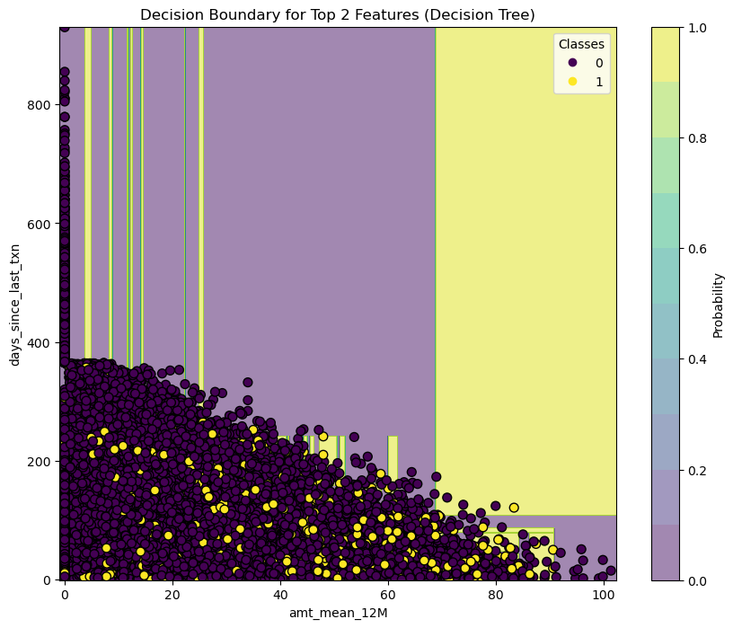

```python
top_2_features = importance_df.iloc[-2:,0].values
X_top2_tree = X_train_monthly[top_2_features]

# Create a meshgrid for plotting the decision boundary
x_min, x_max = X_top2_tree[top_2_features[0]].min() - 1, X_top2_tree[top_2_features[0]].max() + 1
y_min, y_max = X_top2_tree[top_2_features[1]].min() - 1, X_top2_tree[top_2_features[1]].max() + 1
xx, yy = np.meshgrid(np.arange(x_min, x_max, 0.1), np.arange(y_min, y_max, 0.1))

# Train a new Decision Tree model on the top 2 features with the hyperparameters from RandomizedSearchCV
decision_tree_top2 = DecisionTreeClassifier(**best_model_tree_random.get_params())
decision_tree_top2.fit(X_top2_tree, y_train_monthly)

# Create a meshgrid for plotting the decision boundary
xx, yy = np.meshgrid(np.arange(x_min, x_max, 0.1), np.arange(y_min, y_max, 0.1))

# Predict the class labels and probabilities for each point in the meshgrid
Z_tree = decision_tree_top2.predict(np.c_[xx.ravel(), yy.ravel()])
probs_tree = decision_tree_top2.predict_proba(np.c_[xx.ravel(), yy.ravel()])[:, 1]
Z_tree = Z_tree.reshape(xx.shape)

# Plot the decision boundary and training points
plt.figure(figsize=(10, 8))

# Plot decision boundary with color bar
contour = plt.contourf(xx, yy, Z_tree, alpha=0.5, cmap='viridis', levels=np.linspace(0, 1, 11))
cbar = plt.colorbar(contour, label='Probability')

# Plot training points
scatter = plt.scatter(X_top2_tree[top_2_features[0]], X_top2_tree[top_2_features[1]], c=y_train_monthly, cmap='viridis', s=50, edgecolors='k')
plt.legend(*scatter.legend_elements(), title='Classes')

# Set labels and title
plt.title('Decision Boundary for Top 2 Features (Decision Tree)')
plt.xlabel(top_2_features[0])
plt.ylabel(top_2_features[1])

# Show the plot
plt.show()
```

# Random Forest Classifier

```python
# Define the parameter grid for Decision Tree (for GridSearchCV)
param_grid_rf = {'max_depth': [10,12,14,16,18,20],
              'min_samples_split': [2, 4, 6]}
class_weights = {0:0.1,1:0.9}


# Create a Random Forest classifier
random_forest = RandomForestClassifier(class_weight=class_weights,random_state=1147,n_estimators=20)

# ------------------------------------ GRID SEARCH ---------------------------------------------------------#
# Initialize GridSearchCV
grid_search_rf = GridSearchCV(random_forest, param_grid_rf, cv=5)

# Fit the model to the training data
grid_search_rf.fit(X_train_monthly, y_train_monthly)

# Get the best hyperparameters and the best model for GridSearchCV
best_params_rf_grid = grid_search_rf.best_params_
best_model_rf_grid = grid_search_rf.best_estimator_

# Print the best hyperparameters for GridSearchCV
print("The best hyperparameters for the Random Forest model using GridSearchCV are:", best_params_rf_grid)

# --------------------------------- RANDOMIZED SEARCH ------------------------------------------------------#
# Define the parameter distribution for Random Forest (for RandomizedSearchCV)
param_dist_rf = {
    'max_depth': scipy.stats.randint(5, 31),  # None or random integers between 5 and 20
    'min_samples_split': scipy.stats.randint(2, 11),  # Random integer between 2 and 10
    'min_samples_leaf': scipy.stats.randint(1, 11)
}

# Initialize RandomizedSearchCV
random_search_rf = RandomizedSearchCV(random_forest, param_distributions=param_dist_rf, n_iter=10, cv=5, random_state=42)

# Fit the model to the training data
random_search_rf.fit(X_train_monthly, y_train_monthly)

# Get the best hyperparameters and the best model for RandomizedSearchCV
best_params_rf_random = random_search_rf.best_params_
best_model_rf_random = random_search_rf.best_estimator_

# Print the best hyperparameters for RandomizedSearchCV
print("\nThe best hyperparameters for the Random Forest model using RandomizedSearchCV are:", best_params_rf_random)
best_model_rf_random
```

```
The best hyperparameters for the Random Forest model using GridSearchCV are: {'max_depth': 20, 'min_samples_split': 2}

The best hyperparameters for the Random Forest model using RandomizedSearchCV are: {'max_depth': 25, 'min_samples_leaf': 7, 'min_samples_split': 4}
```

```
RandomForestClassifier(class_weight={0: 0.1, 1: 0.9}, max_depth=25,
                       min_samples_leaf=7, min_samples_split=4, n_estimators=20,
                       random_state=1147)
```

```python
# Evaluate the model from GridSearchCV on the test set
y_pred_test_rf_grid = best_model_rf_grid.predict(X_test_monthly)

# Calculate metrics for GridSearchCV
accuracy_rf_grid = accuracy_score(y_test_monthly, y_pred_test_rf_grid)
precision_rf_grid = precision_score(y_test_monthly, y_pred_test_rf_grid)
recall_rf_grid = recall_score(y_test_monthly, y_pred_test_rf_grid)
f1_rf_grid = f1_score(y_test_monthly, y_pred_test_rf_grid)
conf_matrix_rf_grid = confusion_matrix(y_test_monthly, y_pred_test_rf_grid)

# Print metrics for GridSearchCV
print("Random Forest Model Metrics (GridSearchCV):")
print("Accuracy:", accuracy_rf_grid)
print("Precision:", precision_rf_grid)
print("Recall:", recall_rf_grid)
print("F1 Score:", f1_rf_grid)
print("Confusion Matrix:")
print(conf_matrix_rf_grid)

# Evaluate the model from RandomizedSearchCV on the test set
y_pred_test_rf_random = best_model_rf_random.predict(X_test_monthly)

# Calculate metrics for RandomizedSearchCV
accuracy_rf_random = accuracy_score(y_test_monthly, y_pred_test_rf_random)
precision_rf_random = precision_score(y_test_monthly, y_pred_test_rf_random)
recall_rf_random = recall_score(y_test_monthly, y_pred_test_rf_random)
f1_rf_random = f1_score(y_test_monthly, y_pred_test_rf_random)
conf_matrix_rf_random = confusion_matrix(y_test_monthly, y_pred_test_rf_random)

# Print metrics for RandomizedSearchCV
print("\nRandom Forest Model Metrics (RandomizedSearchCV):")
print("Accuracy:", accuracy_rf_random)
print("Precision:", precision_rf_random)
print("Recall:", recall_rf_random)
print("F1 Score:", f1_rf_random)
print("Confusion Matrix:")
print(conf_matrix_rf_random)
```

```
Random Forest Model Metrics (GridSearchCV):
Accuracy: 0.8538889841862967
Precision: 0.16664684898929846
Recall: 0.1380652152497291
F1 Score: 0.15101557028177362
Confusion Matrix:
[[181380  14017]
 [ 17499   2803]]

Random Forest Model Metrics (RandomizedSearchCV):
Accuracy: 0.8456181994353242
Precision: 0.1670594262295082
Recall: 0.1606245690079795
F1 Score: 0.1637788157299985
Confusion Matrix:
[[179138  16259]
 [ 17041   3261]]
```

```python
feature_importance_rf = best_model_rf_random.feature_importances_
feature_names_rf = X.columns
importance_df_rf = pd.DataFrame({'Feature': feature_names_rf, 'Importance': feature_importance_rf})

# Sorting the DataFrame by importance values for better visualization
importance_df_rf = importance_df_rf.sort_values(by='Importance', ascending=True)

# Plotting using Plotly Express
fig_rf = px.bar(importance_df_rf, x='Feature', y='Importance',
                title='Random Forest Feature Importance in Descending Order',
                labels={'Importance': 'Importance Value', 'Feature': 'Feature'})

fig_rf.show()
```

```python
# Getting predicted probabilities  for Random Forest
probabilities_rf = best_model_rf_random.predict_proba(X_test_monthly)[:,1]

# Creating a DataFrame with probabilities for Random Forest
prob_df_rf = pd.DataFrame({'Probability': probabilities_rf, 'Actual': y_test_monthly})

# Plotting using Plotly Express with borders on the bars for Random Forest
fig_rf = px.histogram(prob_df_rf, x='Probability', color='Actual', marginal='box',
                      title='Probability Distribution for Test Set (Random Forest)',
                      labels={'Probability': 'Predicted Probability', 'Actual': 'Actual'},
                      opacity=0.7,
                      barmode='overlay',  # Overlay mode to show bars with borders
                      barnorm='percent',  # Normalize bars to percentage
                      histnorm='probability')

fig_rf.show()
```

```python
# Evaluate the model from GridSearchCV on the train set
y_pred_train_rf_random = best_model_rf_random.predict(X_train_monthly)

# Evaluate the model from RandomizedSearchCV on the test set
y_pred_test_rf_random = best_model_rf_random.predict(X_test_monthly)

# Confusion matrix for train set - RandomizedSearchCV
conf_matrix_train_rf_random = confusion_matrix(y_train_monthly, y_pred_train_rf_random)

# Confusion matrix for test set - RandomizedSearchCV
conf_matrix_test_rf_random = confusion_matrix(y_test_monthly, y_pred_test_rf_random)

# Calculate precision and recall for train set - RandomizedSearchCV
precision_train_rf_random = precision_score(y_train_monthly, y_pred_train_rf_random)
recall_train_rf_random = recall_score(y_test_monthly, y_pred_test_rf_random)

# Calculate precision and recall for test set - RandomizedSearchCV
precision_test_rf_random = precision_score(y_test_monthly, y_pred_test_rf_random)
recall_test_rf_random = recall_score(y_test_monthly, y_pred_test_rf_random)

# Create a list to store the text values for each block - RandomizedSearchCV
text_values_test_rf_random = [
    [f'TN: {conf_matrix_test_rf_random[0, 0]}', f'FP: {conf_matrix_test_rf_random[0, 1]}'],
    [f'FN: {conf_matrix_test_rf_random[1, 0]}', f'TP: {conf_matrix_test_rf_random[1, 1]}']
]

# Create a list to store the text values for each block - RandomizedSearchCV
text_values_train_rf_random = [
    [f'TN: {conf_matrix_train_rf_random[0, 0]}', f'FP: {conf_matrix_train_rf_random[0, 1]}'],
    [f'FN: {conf_matrix_train_rf_random[1, 0]}', f'TP: {conf_matrix_train_rf_random[1, 1]}']
]

# Plotting Confusion Matrix with text values for train set - GridSearchCV
fig_conf_matrix_train_rf_random = go.Figure(data=go.Heatmap(z=conf_matrix_train_rf_random, x=['0', '1'], y=['0', '1'],
                                                          colorscale='Viridis', text=text_values_train_rf_random, hoverinfo='text'))
fig_conf_matrix_train_rf_random.update_layout(title='Train Set Confusion Matrix (Random Forest - RandomizedSearchCV)',
                                             xaxis=dict(title='Predicted', side='bottom'),
                                             yaxis=dict(title='True'), width=1200, height=800)

# Plotting Confusion Matrix with text values for test set - RandomizedSearchCV
fig_conf_matrix_test_rf_random = go.Figure(data=go.Heatmap(z=conf_matrix_test_rf_random, x=['0', '1'], y=['0', '1'],
                                                            colorscale='Viridis', text=text_values_test_rf_random, hoverinfo='text'))
fig_conf_matrix_test_rf_random.update_layout(title='Test Set Confusion Matrix (Random Forest - RandomizedSearchCV)',
                                               xaxis=dict(title='Predicted', side='bottom'),
                                               yaxis=dict(title='True'), width=1200, height=800)

# Show plots for the test set - GridSearchCV
fig_conf_matrix_train_rf_random.show()

# Show plots for the test set - RandomizedSearchCV
fig_conf_matrix_test_rf_random.show()

# Print precision and recall for the test set - GridSearchCV
print("Train Set Precision (Random Forest - GridSearchCV):", precision_train_rf_random)
print("Train Set Recall (Random Forest - GridSearchCV):", recall_train_rf_random)

# Print precision and recall for the test set - RandomizedSearchCV
print("\nTest Set Precision (Random Forest - RandomizedSearchCV):", precision_test_rf_random)
print("Test Set Recall (Random Forest - RandomizedSearchCV):", recall_test_rf_random)
```

```
Train Set Precision (Random Forest - GridSearchCV): 0.6053410152600436
Train Set Recall (Random Forest - GridSearchCV): 0.1606245690079795

Test Set Precision (Random Forest - RandomizedSearchCV): 0.1670594262295082
Test Set Recall (Random Forest - RandomizedSearchCV): 0.1606245690079795
```

```python
# Predicted probabilities for the positive class for test set for Random Forest
probabilities_test_rf = best_model_rf_random.predict_proba(X_test_monthly)[:, 1]
fpr_test_rf, tpr_test_rf, thresholds_test_rf = roc_curve(y_test_monthly, probabilities_test_rf)
roc_auc_test_rf = auc(fpr_test_rf, tpr_test_rf)

# Predicted probabilities for the positive class for training set for Random Forest
probabilities_train_rf = best_model_rf_random.predict_proba(X_train_monthly)[:, 1]
fpr_train_rf, tpr_train_rf, thresholds_train_rf = roc_curve(y_train_monthly, probabilities_train_rf)
roc_auc_train_rf = auc(fpr_train_rf, tpr_train_rf)

# Plotting ROC Curve for both sets for Random Forest
fig_roc_curve_rf = go.Figure()
fig_roc_curve_rf.add_trace(go.Scatter(x=fpr_test_rf, y=tpr_test_rf, mode='lines', name=f'Test Set AUC = {roc_auc_test_rf:.2f}'))
fig_roc_curve_rf.add_trace(go.Scatter(x=fpr_train_rf, y=tpr_train_rf, mode='lines', name=f'Training Set AUC = {roc_auc_train_rf:.2f}'))
fig_roc_curve_rf.add_trace(go.Scatter(x=[0, 1], y=[0, 1], mode='lines', name='Random', line=dict(dash='dash')))
fig_roc_curve_rf.update_layout(title='Receiver Operating Characteristic (ROC) Curve (Random Forest)',
                               xaxis=dict(title='False Positive Rate'),
                               yaxis=dict(title='True Positive Rate'), width=1200, height=800)

# Show the plot for Random Forest
fig_roc_curve_rf.show()
```

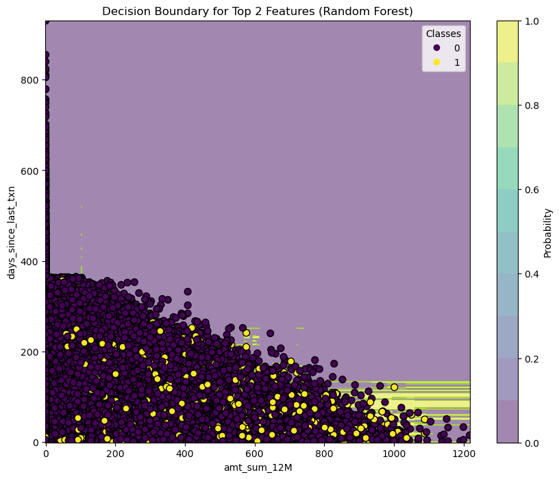

```python
top_2_features = importance_df_rf.iloc[-2:,0].values
X_top2_rf = X_train_monthly[top_2_features]

# Create a meshgrid for plotting the decision boundary
x_min, x_max = X_top2_rf[top_2_features[0]].min() - 1, X_top2_rf[top_2_features[0]].max() + 1
y_min, y_max = X_top2_rf[top_2_features[1]].min() - 1, X_top2_rf[top_2_features[1]].max() + 1
xx, yy = np.meshgrid(np.arange(x_min, x_max, 0.1), np.arange(y_min, y_max, 0.1))

# Train a new Random Forest model on the top 2 features with the hyperparameters from GridSearchCV
decision_rf_top2 = RandomForestClassifier(**best_model_rf_random.get_params())
decision_rf_top2.fit(X_top2_rf, y_train_monthly)

# Create a meshgrid for plotting the decision boundary
xx, yy = np.meshgrid(np.arange(x_min, x_max, 0.1), np.arange(y_min, y_max, 0.1))

# Predict the class labels and probabilities for each point in the meshgrid
Z_rf = decision_rf_top2.predict(np.c_[xx.ravel(), yy.ravel()])
probs_rf = decision_rf_top2.predict_proba(np.c_[xx.ravel(), yy.ravel()])[:, 1]
Z_rf = Z_rf.reshape(xx.shape)

# Plot the decision boundary and training points
plt.figure(figsize=(10, 8))

# Plot decision boundary with color bar
contour = plt.contourf(xx, yy, Z_rf, alpha=0.5, cmap='viridis', levels=np.linspace(0, 1, 11))
cbar = plt.colorbar(contour, label='Probability')

# Plot training points
scatter = plt.scatter(X_top2_rf[top_2_features[0]], X_top2_rf[top_2_features[1]], c=y_train_monthly, cmap='viridis', s=50, edgecolors='k')
plt.legend(*scatter.legend_elements(), title='Classes')

# Set labels and title
plt.title('Decision Boundary for Top 2 Features (Random Forest)')
plt.xlabel(top_2_features[0])
plt.ylabel(top_2_features[1])

# Show the plot
plt.show()
```

# 1.3 Comparison of methods

### Logistic Regression using L1 regularization: Annual v/s Monthly dataset comparison

[output not shown]

### Decision Tree: Annual v/s Monthly dataset comparison

[output not shown]

### Random Forest: Annual v/s Monthly dataset comparison

| Step NO. | Topic | annual_features_outputs | monthly_features_outputs |
| --- | --- | --- | --- |
| 5 | Coefficient values or feature of importance | **Parameters** Hyperparameters considered for tuning: max_depth, min_samples_plit and min_samples_leaf with n_estimators = 20 **The top 2 features are:** ann_txn_amt_sum_2014, ann_txn_amt_sum_2013 | Hyperparameters considered for tuning: max_depth, min_samples_plit and min_samples_leaf with n_estimators = 20 **The top 2 features are:** days_since_last_txn, amt_sum_12M |
| 6 | Probability distribution for test set | The model predicts a considerable amount of negative response compared to positive response. Cumulatively, majority of the clients gave a negative response to the campaign. | The model predicts a considerable amount of negative response compared to positive response. Cumulatively, majority of the clients gave a negative response to the campaign. |
| 7 | confusion matrix, ROC curves of train/test, precision/recall | **Confusion matrix:** TN: 4052 TP: 27 FN: 424 FP: 87 In this model, 87 clients were predicted to have given a positive response but they were actually negative. 424 clients were predicted to have give… | **Confusion matrix:** TN: 179138 TP: 3261 FN: 17041 FP: 16259 In this model, 16259 responses were a positive response but they were actually negative. 17041 responses were predicted to be negative but… |
| 8 | Decision Boundary | The decision boundary for top 2 features was plotted, however, there seems to be no clear decision boundary | The decision boundary for top 2 features was plotted, however, there seems to be no clear decision boundary |

# Conclusion

## Annual Features (best dataset)

## Logistic regression (Best Model)

After evaluating three machine learning algorithms for a binary classification problem, I found that the best model for this particular dataset was Logistic Regression with assigned class weights. The model was assessed using various metrics, including accuracy, precision, recall, F1-score, and the ROC curve (AUC).

The F1-score, combining precision and recall, was highest in Logistic Regression, indicating the model's ability to classify observations correctly.

Analyzing the ROC curve, the Log-Regression model performed well, with an AUC of 0.76 in the test case, indicating effective distinction between positive and negative observations.

When comparing annual features versus monthly features, Random Forest and Decision Tree models performed comparatively better on annual features. Feature importance also highlighted the sum of transactions in 12 months as a significant feature, suggesting that monthly features capturing short-term trends may be less impactful. Annual trends may offer a better measure for creating a predictive model to confirm if a customer might respond positively to a campaign.

Among all models, for the chosen hyperparameter space, Logistic Regression performs well on annual features, better than Random Forest and Decision Trees. While oversampling is an option, the primary concern is the bias it introduces. Creating artificial data may help model the current data but may not be impactful for future predictions.